# Consumers’ response to environmentally-friendly food packaging - A systematic review - ScienceDirect

- [View **PDF**](https://www.sciencedirect.com/science/article/pii/S0959652620301700/pdfft?md5=9eb10b7bae48e5a3a8878b7ac3ae2940&pid=1-s2.0-S0959652620301700-main.pdf)

## [Journal of Cleaner Production](https://www.sciencedirect.com/journal/journal-of-cleaner-production)

[Volume 254](https://www.sciencedirect.com/journal/journal-of-cleaner-production/vol/254/suppl/C), 1 May 2020, 120123

# Review Consumers’ response to environmentally-friendly food packaging - A systematic review

, , [Ulrich Hamm <sup>a</sup>](https://www.sciencedirect.com/author/23018816100/ulrich-hamm)

https://doi.org/10.1016/j.jclepro.2020.120123[Get rights and content](https://s100.copyright.com/AppDispatchServlet?publisherName=ELS&contentID=S0959652620301700&orderBeanReset=true)

Full text access

## Highlights

- •

  Most consumers are aware of the environmental problems caused by food packaging.
- •

  Consumers know little about environmentally-friendly packaging (EFP) solutions.
- •

  Research gaps exist regarding how to increase consumers’ purchases of EFP.
- •

  No study on consumers’ purchases of EFP in the real marketplace conducted so far.

## Abstract

Consumers play an important role in the market penetration of environmentally-friendly food packaging because it is they who decide whether or not to buy a particular product. The objective of this paper is to analyse the state of the art regarding consumers’ response to environmentally-friendly food packaging in order to identify existing barriers to purchase and potential measures to overcome these barriers. The paper is based on a systematic synthesis of 46 scientific journal articles on consumer studies related to environmentally-friendly packaging. The literature review applies a conceptual framework regarding the ways consumers respond to product stimuli and the psychological processes involved. Three important barriers to purchasing environmentally-friendly packaging are identified. First, consumers need guidance in recognizing environmentally-friendly packaging; for while consumers primarily consider the [packaging material](https://www.sciencedirect.com/topics/agricultural-and-biological-sciences/packaging-material) itself and any eco-labels, they also consider other packaging design elements such as colours and pictures of ‘nature’ that can be misleading. Second, it became obvious that consumers lack knowledge, in particular about new packaging materials like bio-based packaging. Third, many of the studies reviewed provide evidence that other product attributes such as price and [product quality](https://www.sciencedirect.com/topics/agricultural-and-biological-sciences/product-quality) are more important to consumers than environmentally-friendly packaging. Nevertheless, some studies recorded a significantly higher willingness on the part of consumers to buy and pay for environmentally-friendly packaging and products with reduced packaging compared to products with standard packaging, signalling an overall positive attitude. The literature review revealed many research gaps. For example, it became obvious that consumers’ response to environmentally-friendly food packaging is not yet well understood, in particular with regards to purchasing behaviour (in the real world as opposed to in a survey setting) and measures for overcoming existing barriers.

- [Previous article in issue](https://www.sciencedirect.com/science/article/pii/S095965262030072X)
- [Next article in issue](https://www.sciencedirect.com/science/article/pii/S095965262030161X)

## Keywords

Packaging

Consumer

Food

Sustainable

Environmentally-friendly

Green

## 1. Introduction

Human activities are causing irreversible environmental effects, such as [climate change](https://www.sciencedirect.com/topics/agricultural-and-biological-sciences/climate-change) and loss of biodiversity (Rockström et al., 2009). A large part of each individual’s [ecological footprint](https://www.sciencedirect.com/topics/agricultural-and-biological-sciences/ecological-footprint) stems from their consumption of products. The production and consumption of more environmentally-friendly products is an important step towards achieving more sustainable lifestyles. At present, however, environmentally-friendly or ‘green’ products are still a niche market. Gleim et al. (2013) estimate the global market share for green products at less than 4%. According to FTSE Russell (2018), the green economy accounts for 6% of the market capitalization of globally listed companies.

A serious side effect of product consumption is the generation of packaging waste. The global packaging market was estimated at 4300 billion packaging units in 2015, of which 73% were for food and drinks (ALL4PACK, 2016). In the European Union, 1130 billion packages were used for food and drinks in 2018 (Fuhr et al., 2019). Since 2010, waste production has grown at an annual rate of 4.2% and is expected to continue at the same rate to 2024. Rigid and flexible plastic is the [packaging material](https://www.sciencedirect.com/topics/agricultural-and-biological-sciences/packaging-material) with the largest market share, at 47% in 2015 (ALL4PACK, 2016).

One way to tackle the waste problem is to introduce environmentally-friendly food packaging (Geueke et al., 2018). The market share of environmentally-friendly packaging is difficult to estimate, however, as there is no common definition (PWC, 2010) and there are many synonyms such as ‘eco-friendly’, ‘sustainable’ and ‘green packaging’ (Prakash and Pathak, 2017). Steenis et al. (2017, p. 278) define sustainable packaging as “packaging that has a comparatively low environmental impact as measured by life-cycle assessment models”. Magnier et al. (2016) take a slightly different approach by focusing on the product’s environmental impact: they define sustainable packaging as “the endeavour to reduce the product’s footprint through altering the product’s packaging, for example, by using more environmentally-friendly materials” (Magnier et al., 2016, p. 132). The definition of sustainable or green packaging developed by Han et al. (2018) is more detailed and covers three levels: raw materials, production processes, and waste management. Regarding raw materials, the authors advocate the use of recycled materials and renewable resources to reduce the use and environmental impact of oil. Environmentally-friendly packaging should be produced in an energy-efficient way and the package should be as light and thin as possible. At the end of its life-cycle, packaging should be biodegradable, reused or recycled (Han et al., 2018).

The implementation of environmentally-friendly packaging requires more serious efforts. Firstly, packaging fulfils important functions that need to be considered when developing environmentally-friendly packaging. The main functions of packaging are protection, storage, loading and transport, sale, promotion, service and guarantee (Lindh et al., 2016b). It should be emphasized that packaging prevents food waste, which is a very important function given that food waste has a higher environmental impact than packaging itself (Molina-Besch et al., 2018, Dilkes-Hoffman et al., 2018). The functions of sale, promotion and service should also not be overlooked. Ultimately it is consumers who determine the market success of packaging through their buying decisions. Indeed, a buying decision is a trade-off between many product attributes. Packaging design is important in communicating the attributes of a product to consumers (Müller Loose and Szolnoki, 2012). For instance, the colour of packaging can influence consumers’ perceived taste of a product (Becker et al., 2011). This makes consumers’ opinions very important in the entire process of packaging design (Grönman et al., 2013), including the design of environmentally-friendly packaging (Boesen et al., 2019).

Consumer awareness and perceptions are only the beginning of a buying decision process. A positive perception of a product does not automatically mean that a person will purchase it, however, since a buying decision is typically influenced by many different factors (Grunert, 2011). The so-called ‘attitude-behaviour gap’ or ‘intention-behaviour gap’ is a well-known phenomenon in the field of sustainable consumer behaviour whereby many consumers’ positive attitude and noble intentions to act in a sustainable way are not translated into actual consumer behaviour. Many studies have investigated potential factors explaining the occurrence of the attitude/intention-behaviour gap in the area of environmentally-friendly behaviour (e.g. Grunert, 2011, Moser, 2016, Sheeran and Webb, 2016, Vermeir and Verbeke, 2006, Kollmuss and Agyeman, 2002). Amongst the barriers to purchasing sustainable products commonly mentioned in the literature across different types of sustainable products are higher prices, lack of availability, and perceived lower quality (Stern, 2000, Hughner et al., 2007, De Jonge and Van Trijp, 2013, Young et al., 2010, Magnier and Crié, 2015).

It is challenging to explain why the attitude/intention-behaviour gap occurs because the reasons often differ from consumer to consumer and a factor preventing one consumer from buying sustainable products might not constitute a barrier for another (Stern, 2000). Accordingly, several studies on sustainable consumer behaviour have applied the consumer segmentation method to identify consumer groups with similar characteristics and distinguish them from groups with different characteristics (Müller and Hamm, 2014). However, each study uses a slightly different set of segmentation criteria, making direct comparisons across studies somewhat difficult. A general finding of previous studies on sustainable product purchases has been that the group of consumers truly dedicated to buying sustainable products is rather small, at less than 10%, although a larger share of consumers hold positive attitudes towards sustainable products.

The objectives of the present review paper are to

- 1)

  analyse the state of the art regarding consumers’ response to environmentally-friendly food packaging,
- 2)

  identify barriers to the purchase of products with sustainable packaging, and
- 3)

  draw conclusions on how to overcome the most important barriers to purchase.

While other sustainable consumption areas such as organic food purchases have already been theorized in detail, a synthesis of previous research on consumer response to environmentally-friendly packaging has so far been lacking. From the body of existing literature it is somewhat difficult to obtain an overview of results that can be generalised, since previous studies have covered various types of packaging materials with different options for disposal (such as recyclability or biodegradability), and because studies have also differed greatly in their focus on the factors influencing consumer behaviour.

To synthesise existing knowledge and identify research gaps, the present review study is based on a conceptual framework for analysing barriers to purchase (Chapter 2). This framework links purchase behaviour related to environmentally-friendly packaging to the psychological processes of awareness and recognition, knowledge and understanding, liking, preference and attitude, conviction, and other influencing factors. The conceptual framework allows conclusions to be drawn regarding the following research questions:

- •

  Are consumers aware of the [environmental impact of food](https://www.sciencedirect.com/topics/food-science/environmental-impact-of-food) packaging? Are they aware of and able to recognise environmentally-friendly packaging solutions?
- •

  What knowledge and perception do consumers have about environmentally-friendly packaging?
- •

  What are consumers’ preferences and attitudes with regard to environmentally-friendly packaging?
- •

  How important is environmentally-friendly packaging to consumers in the buying decision process?
- •

  Are consumers willing to buy and pay price premiums for products with environmentally-friendly packaging?
- •

  How can important barriers to purchase be overcome?

The remainder of this paper is organised as follows. Section 2 introduces the conceptual framework used to synthesise and present the state of the art of consumer studies about environmentally-friendly packaging. Section 3, ‘Methods and material of the literature review’, describes the literature search procedure and the studies included in the review. Section 4, ‘Results and discussion’, presents the synthesis of results, and the final section presents conclusions drawn from the synthesis of results and outlines existing research gaps and recommendations for future research.

## 2. Conceptual framework

The conceptual framework was adapted from Grunert (2011) and Grunert and Wills (2007). Grunert (2011) analysed consumer response to sustainability labels on food and identified barriers to purchase, while Grunert and Wills (2007) applied the framework to explain consumer response to nutrition information on [food labels](https://www.sciencedirect.com/topics/food-science/food-package-labeling). Both frameworks were inspired by the ‘Hierarchy of Effects Theory’ developed by Lavidge and Steiner (1961) to measure the effectiveness of advertising. The original ‘Hierarchy of Effects’ model postulates that “consumers normally do not go from disinterested individuals to convinced purchasers in one instantaneous step” (Lavidge and Steiner, 1961, p. 59) but rather undergo several stages between initial exposure to advertising and final product purchase. This original model has been contested on account of its simplified assumption that consumers undergo these stages of awareness, knowledge, liking, preference, conviction and purchase in a stepwise or chronological order.

The present framework also assumes, much like the original ‘Hierarchy of Effects’ model, that several affective and cognitive processes are involved before consumers react to a stimulus. In contrast to the original model, however, several authors (Grunert and Wills, 2007, Grunert, 2011, Kroeber-Riel and Weinberg, 2003) have argued that these affective and cognitive processes do not occur in a strict stepwise order but may happen simultaneously and influence each other as well. Following this line of thinking, the literature review was based on the framework presented in Fig. 1, which displays in a central box several processes that happen in a consumer’s mind after having been exposed to environmentally-friendly packaging and before reacting to this stimulus. These processes are not directly observable, in contrast to ‘exposure’ and ‘purchase’, which are displayed outside of the box.

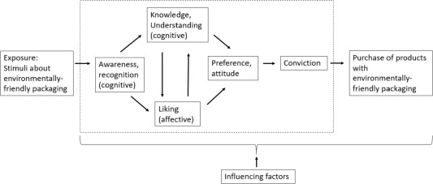

Fig. 1. Conceptual framework adopted from Grunert and Wills (2007) and Grunert (2011).

The framework assumes that environmentally-friendly packaging can only lead to a reaction when consumers are aware of and recognise such packaging. Possible effects include cognitive knowledge and understanding, as well as affective liking. Based on these processes, consumers’ preferences and attitudes may develop, which can lead to the formation of ‘conviction’ (as it was called in the original ‘Hierarchy of Effects Theory’) in favour of products with environmentally-friendly packaging. This conviction can be measured by concepts such as willingness to buy or willingness to pay.

The present review paper has similar objectives as the studies undertaken by Grunert and Wills (2007) and Grunert (2011), which is why this framework was selected over other prominent theories of consumer behaviour. The barriers to the purchase of eco-labelled food identified by Grunert (2011) demonstrate the importance of consumer awareness and perception for understanding consumer reactions and ascertaining why consumers might not purchase particular products. For the purchase of products with environmentally-friendly packaging, lack of awareness on the part of consumers may already constitute a first barrier, since consumers do not expect such labelling to be there and consequently do not search for it (Mancini et al., 2017).

The framework chosen for the present review study covers all stages from awareness to purchase. Other important theories for analysing consumers’ decision-making, including the ‘Theory of Planned Behaviour’ (Ajzen, 1991) and the ‘Theory of Reasoned Action’ (Fishbein and Ajzen, 1975), focus on other factors influencing consumer behaviour but do not adequately capture whether consumers are actually familiar with the stimulus in question. The same limitation applies to other theories relevant to environmentally significant consumer behaviour, such as the ‘Value-Belief-Norm Theory’ (Stern, 2000) or the ‘ABC Theory’ (Guagnano et al., 1995).

## 3. Methods and material of the literature review

### 3.1. Literature search

A systematic literature search was conducted to synthesise existing knowledge on consumers’ responses to environmentally-friendly food packaging. The review procedure was based on the standards developed for systematic literature reviews by Moher et al. (2009). In addition, previous review papers of similar research areas, such as Janssen et al., 2016, Feldmann and Hamm, 2015 and Schäufele and Hamm (2017), provided orientation for the implementation of the review process.

The two most renowned databases for scientific peer-reviewed literature, the Web of Science and ScienceDirect, as well as the AgEcon database, were screened for relevant journal articles and conference papers. The following search term was applied to screen title abstracts and keywords: consumer AND pack* AND (sustainab* OR organic OR ecological* OR environment* OR green OR biologic*).

The search included consumer studies in English from all countries over a ten-year period from January 1, 2008 to July 31, 2018. Publications that did not focus on food or beverage packaging but analysed other product categories such as the packaging of laundry detergent, electronics, take-away food and shopping bags, were excluded. The criterion ‘food or beverage’ was not included in the search term, since many studies directly mention a *specific* food or beverage product (i.e. cheese or bottled water) under analysis without mentioning the term ‘food’ or ‘beverage’.

The steps and records of the database searches are presented in Fig. 2. The Web of Science database yielded 1435 records, while ScienceDirect generated 420 and AgEcon yielded 88. In total, 1943 records were screened. Of these, 1892 articles were excluded since they did not deal with consumer studies on food packaging. Five more articles were excluded because full texts were not accessible. Finally, 46 articles were evaluated as relevant and included in the qualitative synthesis in this review study. The 46 articles are listed in Table 5 in the Appendix.

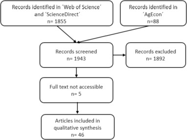

Fig. 2. Flow chart of the procedure for selecting the articles to be reviewed.

The 46 articles were based on data collected in 24 different countries. Most studies were conducted in France (7 articles), followed by the Netherlands, Italy and the USA (5 articles each). The main area of data collection was Europe (39 articles). Interestingly, 33 of the 46 studies were published in the period between 2014 and 2018, while only 13 articles were published between 2008 and 2013.

All of the studies included in this review article investigated factors in some way connected to consumers’ buying behaviour in relation to environmentally-friendly food packaging. Interestingly, we observed important differences across the studies in terms of the role of environmentally-friendly packaging in the research objectives of the studies. In 21 studies, the research objectives directly addressed the topic of environmentally-friendly packaging. In the other 25 studies, however, environmentally-friendly packaging was only a side issue, either because their structured interview formats included only a few items on this topic or because aspects of environmentally-friendly packaging arose only due to being raised by participants themselves in open-ended research formats. These 25 studies focussed on requirements for packaging, consumer perception of and preferences for packaging in general (18 studies), sustainable or environmental behaviour in general or in relation to food in particular (6 studies), and bio-based products (1 study).

### 3.2. Theoretical foundations of the studies reviewed

Table 1. Theoretical foundations of the studies reviewed.

| Theoretical foundations | Number of articles |
| --- | --- |
| *Theories on attitude-behaviour relationships* Theory of Reasoned Action (Fishbein and Ajzen, 1975) and/or Theory of Planned Behaviour (Ajzen, 1991) | 13 |
| *Theories on consumer preferences and willingness to pay* Microeconomic foundations, i.e. utility maximisation and/or Random Utility Theory (McFadden, 1974) | 11 |
| *Theories on cue utilization and signalling* Information economics, e.g. Cue Utilization Theory (Olson and Jacoby, 1972) and Signalling Theory (Spence, 1973, Stigler, 1961) | 9 |
| *Other theoretical foundations* Focus on (selected) processes in the consumer organism | 18 |

Note. Several articles were assigned to two categories.

*Theories on attitude-behaviour relationships*: Thirteen of the studies analysed relationships between attitudinal constructs and behavioural intention with explicit or implicit reference to the Theory of Reasoned Action (Fishbein and Ajzen, 1975) and/or the Theory of Planned Behaviour (Ajzen, 1991). These studies cover a variety of different attitudinal constructs, including constructs in the tradition of the Theory of Planned Behaviour, such as consumer beliefs about environmentally-friendly food consumption (Tobler et al., 2011, Lea and Worsley, 2008), personal/subjective norms (Martinho et al., 2015, Prakash and Pathak, 2017), and perceived behavioural control (Martinho et al., 2015), as well as attitudinal constructs related to environmental issues in general, e.g. environmental concern (Trivedi et al., 2018, Prakash and Pathak, 2017, Koenig-Lewis et al., 2014) and awareness of environmental problems (Van Birgelen et al., 2009).

*Theories on consumer preferences and willingness to pay*: Eleven of the studies analysed consumer preferences, willingness to pay (WTP) or willingness to buy (WTB) with regard to food products with environmentally-friendly packaging, applying the method of choice experiments (Klaiman et al., 2016, Rokka and Uusitalo, 2008), conjoint analysis (Arboretti and Bordignon, 2016, Koutsimanis et al., 2012), contingent valuation (Ertz et al., 2017, Neill and Williams, 2016), or other methods (Van Herpen et al., 2016, Singh and Pandey, 2018). These studies include explicit or implicit references to microeconomic foundations such as utility maximisation and/or Random Utility Theory (McFadden, 1974).

*Theories on cue utilization and signalling*: Nine of the studies analysed the relationship between product packaging (material, design and/or labelling) and consumers’ product perception and evaluation. Studies in this category investigated, for example, how environmentally-friendly packaging affects perceived [product quality](https://www.sciencedirect.com/topics/agricultural-and-biological-sciences/product-quality) (Ertz et al., 2017, Magnier et al., 2016) or how package design and labelling elements influence consumer perceptions of the environmental-friendliness of packaging (Ertz et al., 2017, Magnier and Crié, 2015). The studies in this category have explicit or implicit foundations in information economics, e.g. Cue Utilization Theory (Olson and Jacoby, 1972) or Signalling Theory (Spence, 1973, Stigler, 1961).

*Other theoretical foundations*: Eighteen of the studies did not fall into one of the fields outlined above. These studies mostly focussed on (selected) processes in the consumer organism and covered a wide variety of constructs, including consumer perception, knowledge, affection/emotions, expectations and attitudes. These studies are mostly either exploratory or descriptive in nature. Eight of the ten qualitative studies in the review were assigned to this category. Some of the studies in this category also collected data on reported behaviour but without analysing statistical relationships to attitudinal constructs (e.g. Scott and Vigar-Ellis, 2014), which is why they were not grouped under the attitude-behaviour category described above.

Overall, a wide variety of concepts from consumer behaviour theory were analysed in the 46 studies. Some of these concepts differed in their terminology from the psychological processes included in the conceptual framework of our literature review (see Fig. 1). In the synthesis of results, we linked all concepts from the studies reviewed to one of the psychological processes of our conceptual framework. For example, ‘perception’ was linked to ‘knowledge and understanding’, ‘emotions’ to ‘liking’, and ‘willingness to pay’ to ‘conviction’.

### 3.3. Research methodologies of the studies reviewed

The great majority of articles reviewed presented results from quantitative research approaches (36 articles). Eight of the articles were based on qualitative research approaches, while only 2 articles presented results from mixed method approaches (Table 2). It is striking that there was little variety regarding the method of data collection applied in the quantitative studies: 34 articles were based on surveys, while experiments and other methods were only applied in relatively few studies.

Table 2. Number of articles per method of data collection.

| Method of data collection | Number of articles<sup>a</sup> | Number of participants (min–max) |
| --- | --- | --- |
| Quantitative (n = 38) |  |  |
| Survey | 34 | 60–2001 |
| Experiment | 4 | 100–302 |
| Eye-Tracking | 1 | 89 |
| Implicit Association Test | 1 | 89 |
| Free choice profiling method | 1 | 249 |
| Qualitative (n = 10) |  |  |
| Focus group | 5 | 12–89 |
| Interview | 4 | 8–195 |
| Projective technique | 1 | 25 |

**a**

Several articles used more than one method of data collection.

To our surprise, most articles were based on convenience samples (20 studies), while another 17 articles did not clearly specify the sampling method used (Table 3). Only 4 studies applied elements of probability sampling methods.

Table 3. Number of articles per sampling method.

| Sampling method | Number of articles<sup>a</sup> |
| --- | --- |
| No information | 17 |
| Convenience sampling | 20 |
| *Snowball* | *10* |
| *Students* | *6* |
| *Other* | *4* |
| Quota sampling | 7 |
| Elements of probability sampling methods | 4 |

**a**

Several articles used more than one sampling method.

## 4. Synthesis of study results

This chapter is organised according to the conceptual framework presented in Fig. 1, beginning with the exposure stage and proceeding to consumers’ awareness and recognition, knowledge and understanding, liking of environmentally-friendly packaging, preference for and attitude towards, conviction for, and purchase of environmentally-friendly packaging.

### 4.1. Exposure

In the context of this literature synthesis, ‘exposure’ refers to the question of how the participants of the different studies were exposed to the topic of environmentally-friendly packaging. This section gives an overview of the use of terms applied for environmentally-friendly packaging in the original questionnaires or interviews, and the stimuli used in the studies.

With regard to how the participants of the studies were exposed to the topic of environmentally-friendly packaging, we distinguished between stimuli *format* and stimuli *content*. In terms of stimuli *format*, 31 studies used stimuli only in text format, including written and spoken questions, instructions and information about environmentally-friendly packaging. In addition to text stimuli, 16 studies presented participants with real products, empty packages or pictures of products or logos (Table 4).

Table 4. Stimuli content, stimuli format and method of data collection of the reviewed studies.

| Empty Cell | Empty Cell | **Stimuli content** Environmentally-friendly packaging in general | **Stimuli content** Recycling of packaging | **Stimuli content** Packaging in general | **Stimuli content** Unpackaged food/less packaging | **Stimuli content** Bio-based packaging and Bio-degradable packaging | **Stimuli content** Others<sup>c</sup> | Number of studies<sup>a</sup> |  |
| --- | --- | --- | --- | --- | --- | --- | --- | --- | --- |
| Stimuli format | Text stimuli only | 10 | 10 | 4 | 3 | 4 | 8 |  | 31 |
|  | Pictures of products or logos | 1 | 6 | 0 | 4 | 2 | 2 | 12 |  |
|  | Real products or empty packaging | 1 | 0 | 0 | 2 | 0 | 3 | 4 |  |
| Method of data collection | Questionnaire | 9 | 14 | 1 | 5 | 5 | 8 | 34 |  |
|  | Experiment | 1 | 1 | 0 | 3 | 0 | 0 | 4 |  |
|  | Focus group | 0 | 0 | 3 | 1 | 0 | 2 | 5 |  |
|  | Interview | 1 | 1 | 0 | 0 | 0 | 3 | 4 |  |
|  | Other methods<sup>b</sup> | 0 | 1 | 0 | 0 | 1 | 1 | 4 |  |
| Number of studies<sup>a</sup> |  | 11 | 16 | 4 | 9 | 6 | 13 |  |  |

**a**

Several articles used more than one method of data collection or stimuli content and therefore the column/line ‘number of studies’ does not equal the sum of all columns/lines.

**b**

Other methods include IAT, eyetracking, free choice profiling, and projective techniques.

**c**

E.g. reuse of packaging, returnable packaging, low energy packaging, FSC logo.

Interestingly, only 25 articles provided information about the original wording of the stimuli used in the study. Fourteen of the other articles outlined the stimuli presented to the participants without directly replicating the original wording in the article. The remaining seven studies used pictures of products or real packaging without labels or written information referring to environmental friendliness. Of the 16 studies that used a picture or real product stimuli, only 9 presented pictures of the stimulus in the article.

Table 4 also provides information about the combination of stimuli content and format, as well as stimuli content and methods of data collection. From this table it is apparent that the ‘text stimulus only’ format was most common in studies of environmentally-friendly packaging in general, while specific packaging solutions were investigated relatively more often with more specific stimulus formats such as real products and packages or pictures of these.

In addition to a wide range of different types of environmentally-friendly packaging, the studies investigated many different products. In total, 24 of the 46 articles focused on specific products: beverages (11 studies), [dairy products](https://www.sciencedirect.com/topics/food-science/dairy-product) (8 studies), sweets (6 studies), vegetables (5 studies), fruits (3 studies), ready-to-eat meals (2 studies), [canned food](https://www.sciencedirect.com/topics/food-science/canned-food), fresh produce in general, and nuts (1 study each).

### 4.2. Awareness and recognition

Only seven of the 46 studies reviewed provided results related to consumers’ awareness of environmentally-friendly packaging and how consumers recognise such packaging. The results of three studies provide evidence that consumers are generally aware of the [environmental impact of food](https://www.sciencedirect.com/topics/food-science/environmental-impact-of-food) packaging (Venter et al., 2011, Steenis et al., 2017, Banterle et al., 2012). When university students in the Netherlands tested various types of food packaging in terms of how they differed, sustainability cues on food packaging proved highly salient for most students; the only attribute mentioned more often than sustainability was that of convenience (Steenis et al., 2017). In focus group discussions conducted in Italy, the participants mentioned that there was no information in supermarkets about the sustainability, recyclability and reusability of packaging, noting that they would be interested in having such additional information (Banterle et al., 2012).

Four studies investigated how consumers identify environmentally-friendly packaging of food products. The results of these studies showed that labels, logos and packaging material were the most important features for consumers in identifying environmentally-friendly packaging. In addition, consumers used a wide range of other features. In a study conducted in South Africa by Scott and Vigar-Ellis (2014), 45% of the participants stated they looked for labels, while 30% looked for images or logos such as the recycling logo. The packaging material itself was used by 18% of the participants to judge if packaging was sustainable. Furthermore, consumers paid attention to other signs on packaging such as the colour. For these consumers, ‘earth’ colours such as cream, brown or green were indicators of greater sustainability. In addition, plain packaging with only a little colour or ink was felt to be environmentally-friendly. In this study, only 12% of the participants admitted not knowing the difference between sustainable and other packaging. In contrast to the results of Scott and Vigar-Ellis (2014), a study in Sweden by Lindh et al. (2016a) revealed that 27% of the participants considered packaging material in general when purchasing food, while 20% of the participants considered the quantity of packaging and 18% looked for recyclable material. A qualitative research study conducted in France by Magnier and Crié (2015) revealed a broad spectrum of cues for ecological packaging. In their interviews the participants mentioned the following aspects: the reduction of over-packaging, the size and shape of packaging, the use of larger instead of smaller containers, non-diluted products (concentrates), unpackaged and non-pre-packaged products, refilled products, recycled, recyclable and biodegradable packaging, material made from renewable resources, material weight, and reusable packaging. The participants also mentioned eco-labels (e.g. carbon footprint), licensing agreements (e.g. with environmental organisations), pedagogical attributes (e.g. ecological quizzes and information about waste sorting), environmental claims (e.g. ecological, biological, pure, honest) and scientific and environmental attributes (e.g. BPA-free). In contrast to findings suggesting that many consumers know what to look for in order to identify environmentally-friendly packaging, however, a study in Italy by Mancini et al. (2017) found low awareness of the ‘Forest Stewardship Council’ (FSC) logo among focus group participants with a low to medium level of education, who had difficulties understanding the meaning of the logo.

### 4.3. Knowledge and understanding

#### 4.3.1. Understanding and definition of environmentally-friendly packaging

Five of the studies reviewed gave evidence of how consumers defined environmentally-friendly packaging and how familiar they were with terms related to such packaging. In a study of Polish and French university students undertaken by Jerzyk (2016), only 30% of the Polish students had already heard the term ‘sustainable packaging’, as compared to 71% of the French students. What the students in this study found most important about sustainable packaging was that it should be recyclable, while other major considerations included whether such packaging is safe for human health and whether it is made from recycled material. In a consumer study in South Africa, 49% of participants defined the term ‘environmentally-friendly packaging’ as packaging that is non-harmful to humans and the environment. Further features noted by participants included degradability (41%) and recyclability (37%) (Scott and Vigar-Ellis, 2014). These aspects were also important to consumers in a study in India, who further declared their willingness to pay a price premium for environmentally-friendly packaging (Singh and Pandey, 2018).

A study by Herbes et al. (2018) revealed interesting differences between consumers’ responses in France, Germany and the USA. The survey contained the following open-ended question: “For you, what makes packaging material green? (i.e. environmentally-friendly) Please list as many answers as necessary.” In summary, the survey found that consumers from Germany were more focused on attributes at the beginning of the packaging life cycle (e.g. features of the raw materials used) than the participants from France and the USA, who were more focused on factors at the end of this cycle (e.g. reusability, recyclability and degradability). In all three countries, the survey participants rarely mentioned reduced quantity of packaging as a strategy and feature of environmentally-friendly packaging. The packaging materials mentioned most frequently as being ‘green’ were paper and cardboard, followed by glass.

Two of the studies reviewed provided insights into the extent to which consumers are familiar with bio-based packaging (Sijtsema et al., 2016, Koutsimanis et al., 2012). Sijtsema et al. (2016) implemented focus group discussions in five European countries (the Czech Republic, Denmark, Germany, Italy, and the Netherlands) and explored consumers’ reactions to seven bio-based food and non-food products already on the market. There was a high level of uncertainty among participants about the term ‘bio-based’ and the environmental impact of bio-based packaging, including doubts as to whether the term ‘bio-based’ describes a product or a production technique, whether it means the packaging is biodegradable or refers to energy produced in a bio-based way, and whether such packaging is aimed at waste reduction. Only a few people were aware that bio-based materials are produced using renewable resources as opposed to [fossil fuels](https://www.sciencedirect.com/topics/agricultural-and-biological-sciences/fossil-fuel). When asked to link the term ‘bio-based’ to keywords on a list, the participants most often associated ‘bio-based’ with the development of technologies. Other keywords commonly linked to the term included ‘bio fuel’, ‘biodegradable’, ‘environmentally-friendly’, ‘organic’, and ‘biotechnology’. (Unfortunately, the study did not present results differentiated by country of data collection.) In a study of US consumers conducted by Koutsimanis et al. (2012), only 55% of the participants answered correctly to the question: “Which raw materials are used to produce containers of bio-based plastic?”

#### 4.3.2. Perceived environmental impact of different food packaging materials

Twelve of the studies reviewed gave evidence of how consumers perceived the environmental impact of different food packaging materials. These studies analysed a variety of different materials, including glass, metal, cardboard, plastic, recyclable packaging, reusable packaging, bio-based packaging and biodegradable packaging, as well as over-packaging.

The majority of consumers participating in these studies identified the environmental impact of packaging as being primarily dependent on the materials used for packaging (Steenis et al., 2017, Lindh et al., 2016a). Steenis et al. (2017) found that students from the Netherlands judged glass and bioplastics to be most sustainable, followed by cardboard, while plastic and metal were judged least sustainable. (The stimuli used in the study were tomato soup products.) A focus group discussion with elderly participants (aged over 60) conducted in New Zealand by Duizer et al. (2009) confirmed that glass packaging was regarded by consumers as being more environmentally-friendly than other materials. In contrast to this result, 79% of Swedish consumers rated paper-based packaging as the most sustainable packaging, while only 9% rated glass as most sustainable. Similar to the findings of the study by Steenis et al. (2017), plastic and metal were perceived as the least sustainable packaging materials (Lindh et al., 2016a). In line with these findings, the participants of focus group discussions in Sweden conducted by Fernqvist et al. (2015) preferred paper to plastic packaging and engaged in extensive discussion of the negative environmental impact of plastic packaging.

Two studies, one undertaken in Turkey by Aday and Yener (2014), and the other in South Africa by Venter et al. (2011), provided information about which aspects of packaging materials consumers perceived as negative for the environment. The consumers in these studies perceived plastic and glass as being difficult to recycle (Aday and Yener, 2014) and plastic as not being biodegradable (Venter et al., 2011). Nevertheless, only 24% of consumers in Turkey thought there was a problem with environmental pollution as a result of plastic packaging, although 70% of the participants agreed that glass supports ‘healthy nature’ (Aday and Yener, 2014). In the study by Venter et al. (2011), cardboard was also seen as problematic and perceived as a contributor to pollution because product packaging with cardboard often entails additional packaging material. In a study conducted in the Netherlands by Steenis et al. (2017), consumers were also asked about their perception of the environmental friendliness of packaging material, revealing that these consumers’ perceptions are not in line with [life cycle assessments](https://www.sciencedirect.com/topics/agricultural-and-biological-sciences/life-cycle-engineering). For example, consumers incorrectly rated the packaging options judged most sustainable by the life-cycle assessment (i.e. dry cardboard sachets and mixed material pouches) as least sustainable. Likewise, the packaging materials judged as most sustainable by the participants (glass and bioplastic) are rated the least sustainable according to the life-cycle assessment. It must also be mentioned that there was little consensus among the participants as to the sustainability of the 14 different packaging options (in terms of materials and appearance). In their study on organic food packaging, Lindh et al. (2016a) found that 56% of the participants did not know whether such packaging was sustainable or not.

Finally, Herbes et al. (2018) asked consumers in France, Germany and the United States how they perceived the environmental friendliness of different packaging materials. The participants in France and the US rated the packaging option made from recyclable material as the most environmentally-friendly, whereas in Germany the reusable packaging option was rated as best. Participants in Germany rated recyclable material second in terms of environmental friendliness, while in France and the US the participants rated biodegradable plastic from renewable resources (other than bio-methane) as second. In all three countries, plastic packaging made from bio-methane was rated as least environmentally friendly, followed by non-biodegradable plastic from renewable resources (other than bio methane).

### 4.4. Liking

Only two of the reviewed articles included in this study provided evidence on consumers’ affective liking of environmentally-friendly packaging. The study undertaken in Norway by Koenig-Lewis et al. (2014) found evidence of emotional effect arising from the perceived ecological benefits of a partly plant-based water bottle. Not surprisingly, the positive emotions evoked by packaging were significantly influenced by the perceived benefits of the packaging, while negative emotions arose when participants were uncertain about the ecological benefits of the packaging. Koenig-Lewis et al. (2014) also found that the positive and negative emotions evoked by partly plant-based packaging had a strong impact on purchase intention. More specifically, the effect of positive emotions on purchase intention was found to be greater than that of negative emotions. In contrast, the cognitive benefits associated with the packaging did not directly influence purchase intention.

In a qualitative study conducted in five European countries, Sijtsema et al. (2016) revealed that consumers had positive, negative and mixed feelings towards bio-based products. Positive feelings were connected to aspects such as the packaging being good for the environment, natural, healthy, or innovative. Negative feelings were aroused when people were not familiar with the concept of bio-based packaging or perceived it as a marketing trick.

### 4.5. Attitudes and preferences

#### 4.5.1. Attitudes towards environmentally-friendly packaging

Fourteen studies revealed which advantages and disadvantages consumers ascribed to environmentally-friendly packaging and how consumers evaluated specific packaging materials. Regarding environmentally-friendly packaging in general, 64% of the participants in a study undertaken in South Africa by Scott and Vigar-Ellis (2014) stated that buying environmentally-friendly packaging added to their quality of life. When asked how it added to quality of life in an open-ended question, the participants referred to six themes, including the following: 22% stated that environmentally-friendly packaging would improve sustainability and save the planet; 13% stated that it gave them a good feeling; 13% thought it reduced waste; and 11% said they felt such packaging was good for health and prevented serious illnesses. In line with these results, a study of French consumers by Magnier and Crié (2015) found that protection of the environment and the well-being of others were perceived benefits of sustainable packaging, while private benefits included health-related benefits, social value, emotional value, convenience (decrease of packaging volume and ease of disposal) and decrease in price due to reduction in the amount of packaging material. Furthermore, 51% of the participants in a study conducted by Scott and Vigar-Ellis (2014) in South Africa believed that environmentally-friendly packaging would save money. In contrast to this result, the consumers in the study conducted by Magnier and Crié (2015) expected such packaging to entail an increase in price and a decrease in convenience leading to reduced pleasure during consumption. Other perceived costs of environmentally-friendly packaging included a decline in aesthetics, quality, hygiene, product protection, and efficiency (Magnier and Crié, 2015).

Other studies investigated the influence of environmentally-friendly packaging on perceived [product quality](https://www.sciencedirect.com/topics/agricultural-and-biological-sciences/product-quality), naturalness, environmental friendliness, convenience, cost, and company credibility. Magnier et al. (2016, France) revealed in two approaches that when packaging looked more sustainable the participants perceived the products (chocolate, raisins, coffee) to be of better quality than the same products without sustainable packaging. In the case of coffee, sustainable packaging led consumers to perceive the product as more ‘natural’. The authors found that the participants even perceived unhealthy products as more natural and therefore healthier, tastier, and ultimately of better quality because of sustainable packaging. However, in contrast to the results for conventional coffee, there was no effect of sustainable-looking packaging on the perceived quality and naturalness of organic coffee. In a study in France by Monnot et al. (2015) the researchers found that the elimination of over-packaging had a significant positive effect on consumers’ perception of environmental friendliness, convenience and cost, though there was no significant effect on the perceived quality of the product. The results of a study in Canada by Ertz et al. (2017) showed that, in the case of cereal bar packaging, an increased amount of self-declared environmental claims (“less cardboard is used”) did not influence consumers’ perception of product quality or of the companies’ credibility with respect to its environmental activities. However, when an elaborate, self-declared environmental claim was combined with a third-party label, the perceived product quality and credibility of the company were significantly higher.

Five studies documented negative consumer attitudes towards over-packaging: Venter et al., 2011, Clonan et al., 2010, Hanssen et al., 2017, Tobler et al., 2011; and Lea and Worsley (2008). In two of these studies, the majority of consumers stated there was too much packaging on products (Clonan et al., 2010, UK; Hanssen et al., 2017, Norway). Two other studies found that consumers perceived reduction of packaging as important for saving the environment (Tobler et al., 2011, Switzerland; Lea and Worsley, 2008, Australia). In the study conducted by Lea and Worsley (2008), 50% of the participants strongly agreed that it helps the environment when food manufacturers use less packaging.

Regarding bio-based packaging, two studies found that consumers were sceptical and uncertain as to the benefits of such material (Sijtsema et al., 2016, Herbes et al., 2018). In focus group discussions held in five European countries, consumers showed both positive perceptions of bio-based packaging (good for the environment or natural, healthy, energy-related, and innovative) and negative perceptions. Participants who were not familiar with the term ‘bio-based’ or who perceived it as a marketing gimmick questioned whether bio-based packaging was truly innovative, environmentally-friendly and healthy (Sijtsema et al., 2016). The study by Herbes et al. (2018) revealed that consumers in France, Germany and the USA felt uncomfortable about using packaging made from biomethane, both for environmental reasons in general as well as specifically for its lack of biodegradability. Only the German participants in the study showed some concern regarding ethical factors and the disposal of such packaging.

With regard to reusable packaging and recyclable materials, several studies recorded positive consumer perceptions, including a study in Finland and the Netherlands by Heiniö et al. (2017) and in South Africa by (Venter at al. 2011). One study in Belgium by Songa et al. (2018) focused on the research question of how implicit and explicit attitudes and emotional reactions are triggered by recyclability logos. The results of the tests revealed a positive implicit attitude (measured with an implicit attitude test) and explicit attitude (measured with a questionnaire) towards recyclability. In line with these results, the participants’ emotional reaction (measured with eye-tracking) to yoghurt products with a recyclability logo was also positive. Not surprisingly, the participants evaluated the products with a recyclability logo more positively than the products with the logo stating that the packaging was not recyclable.

#### 4.5.2. Preferences for environmentally-friendly packaging

Fourteen studies reviewed for this article provided findings on the importance of environmentally-friendly packaging to consumers. In a study of consumers in Italy, Mancini et al. (2017) found that focus group participants with medium to low levels of education evinced little interest in sustainable packaging material. Amongst students in Poland, Jerzyk (2016) found sustainable packaging was of little importance in the buying decision process, though most respondents stated that they expected the importance of sustainable packaging for consumers to increase in the future. In a questionnaire conducted in Australia by Lea and Worsley (2008), only 20% of the participants stated that they frequently avoided buying products with non-environmentally-friendly packaging, while 45% said they sometimes avoided such packaging, 26% rarely, and 9% never. Students in a study conducted in Spain by Rodríguez-Barreiro et al. (2013) said they would rather not consider types of packaging when buying a product.

Several studies have found that environmentally-friendly packaging is less important to consumers than other product attributes. Martinho et al. (2015) found that sustainable packaging was less important to the participants of their study in Portugal than product quality and price, although more important than packaging design. The results of a study in Denmark by Nørgaard Olesen and Giacalone (2018) were similar, showing that environmentally-friendly packaging of carrots was important to only 15% of the participants, while the following aspects were important to a larger share: transparent packaging, organic quality, Danish origin, and the ‘nice and clean’ appearance of the carrots. The only aspect rated less important than environmental packaging was familiarity with the brand. Baruk and Iwanicka, 2015, Baruk and Iwanicka, 2016 found in their study in Poland that the eco-friendliness of the packaging of [dairy products](https://www.sciencedirect.com/topics/agricultural-and-biological-sciences/dairy-product) was of medium importance to participants during the buying process, while attributes considered more important than eco-friendly packaging included the expiry date, the brand, the regional origin of the product, the unit size of the packaging, and the ease with which packaging could be used. The inclusion of information about the company’s webpage, a helpline and the quality management system were deemed least important. Furthermore, a study in New Zealand by Duizer et al. (2009) revealed that elderly consumers ranked the recyclability of packaging fourth in importance when choosing food products. The price of the product, the safety and the size of the packaging were all considered more important than the recyclability of the packaging. The results of a study by Jerzyk (2016) showed that student participants in France and Poland would not accept any modification of packaging to protect the environment that might also decrease the quality of the product. Surprisingly, Van Birgelen et al., 2009 found that only price and taste were more important than environmentally-friendly packaging for consumers in Germany when buying a product. Product brand and design were attributes that the participants in this study were specifically willing to trade-off for more eco-friendly packaging.

A study of consumers in the UK by Clonan et al. (2010) revealed that the highest priority for participants in terms of sustainable food was how the food had been produced, followed by packaging and seasonality. The findings of Hanss and Böhm (2012) study in Norway indicated that consumers rated recyclable packaging and low-energy packaging as important product attributes for sustainable products, while product attributes related to natural wholesomeness, animal protection, and economic attributes were perceived as less relevant.

Regarding the importance of environmentally-friendly packaging in relation to other packaging attributes, a study in Turkey by Aday and Yener (2014) observed that the recyclability of packaging and its non-harmfulness to nature (12%) were ranked third in order of importance by the participants. The most important attributes for these consumers were that packaging provided food-related information (47%) and that it was easy to use and store (36%). Only one aspect was ranked as less important than the environmental-friendliness of packaging and this was the packaging’s ease of transport (5%). Interestingly, Arboretti and Bordignon (2016) found from their study of consumers in Italy that the aspect of disposal (i.e. whether the packaging is recyclable, non-recyclable or biodegradable) was most important compared to other packaging attributes. The participants regarded biodegradable packaging as having many advantages over recyclable and non-recyclable packaging.

### 4.6. Conviction

#### 4.6.1. Willingness to buy environmentally-friendly packaging

Seven of the studies reviewed provide substantial evidence of consumers’ willingness to buy environmentally-friendly packaging. Magnier and Schormans (2015, Netherlands) found that the ecological appearance of packaging positively influenced Dutch consumers’ purchasing decisions when buying nuts. In addition, 66% of the students in a study conducted by Jerzyk (2016) in France and Poland stated they would buy a different product if it had sustainable packaging, while only 6% said that they would definitely not do so.

A study in South Korea by Seo et al. (2016) compared the influence of eco-friendly packaging and eco-friendly ingredients on consumers’ willingness to buy (WTB). Interestingly, the authors found different results for different types of products, recording a significantly higher WTB for jellybeans and energy drinks with eco-friendly packaging than for products with eco-friendly ingredients and conventional packaging. For yogurt drinks, however, the opposite was true: eco-friendly ingredients evoked a higher WTB than eco-friendly packaging. For protein bars there were no significant differences in WTB between eco-friendly packaging and eco-friendly ingredients.

Regarding packaging made of bio-based materials, Koutsimanis et al. (2012) found that the participants in a study in the USA significantly preferred bio-based materials to petroleum-based packaging, although overall this aspect did not have a strong influence on consumers’ [product evaluation](https://www.sciencedirect.com/topics/agricultural-and-biological-sciences/product-evaluation). In a conjoint analysis, product evaluations were found to be mostly influenced by price (25%), followed by shelf life (19%) and container size (17%). A study on consumers’ perceptions of recyclable packaging in Finland (Rokka and Uusitalo, 2008) concluded that the attributes of ‘price’ and ‘recyclable carton packaging’ had similar relative importance values based on conjoint analysis (35% and 34%), while the ‘re-sealability of the packaging’ and the ‘brand’ had relatively low values (17% and 15%).

#### 4.6.2. Willingness to pay for environmentally-friendly packaging

Several studies analysed consumers’ willingness to pay (WTP) or intention to pay a price premium for environmentally-friendly packaging. These studies applied discrete choice analysis, contingent valuation and other methods. It is problematic to compare the absolute WTP values across these studies since the WTP was measured under very different conditions and the results of conjoint analysis and choice experiments need to be interpreted within the context of each experimental setting. Therefore, we do not report concrete WTP values in this section.

Most studies found that the majority of consumers were willing to pay a price premium for environmentally-friendly packaging, including 86% of participants in a study conducted in Sweden (Lindh et al., 2016a), 81% of participants in a study conducted in the USA (Neill and Williams, 2016), and 67% of participants in a study in Germany (Van Birgelen et al., 2009). In their study of US consumers, Klaiman et al. (2016) investigated the WTP for the recyclability of different packaging materials for fruit juice and found a significantly higher WTP for the recyclability of plastic than for the recyclability of glass and the recyclability of cartons. In addition, consumers in a study in France by Orset et al. (2017) stated the highest WTP for bottles made from r-PET (recycled material, 100% recyclable), and for the PLA bottles (biodegradable), followed by PEF (renewable material, 100% recyclable, not biodegradable), while the lowest WTP was recorded for [PET](https://www.sciencedirect.com/topics/agricultural-and-biological-sciences/polyethylene-terephthalate) bottles (petroleum, 100% recyclable, not biodegradable). In contrast to studies that recorded a positive WTP, consumers in a study from Canada were not willing to pay more for a reduction in the material used in cardboard packaging (Ertz et al., 2017), while Barber (2010) found that only 28% of the participants in a US study were willing to pay more for green packaging for wine.

### 4.7. Purchase of products with environmentally-friendly packaging

None of the studies analysed consumer behaviour in the real marketplace, e.g. through test markets or consumer purchase panels, and we accordingly conclude that none of the reviewed studies provided evidence on consumers’ real purchase behaviour concerning products with environmentally-friendly packaging.

Instead, 19 of the 46 reviewed studies investigated consumers’ intention to buy, willingness to buy or willingness to pay for environmentally-friendly packaging, while 20 other studies discussed their results with respect to purchase behaviour. However, drawing conclusions regarding purchase behaviour based on self-reported attitudes or intended/stated behaviour is problematic due to the well-known phenomenon of attitude/intention-behaviour gap (Janssen, 2018, Moser, 2016, Sheeran and Webb, 2016). Only six of the reviewed studies discussed their results in light of the attitude-behaviour gap (i.e. Trivedi et al., 2018, India; Scott and Vigar-Ellis, 2014, South Africa; Wang et al., 2014, China; Fernqvist et al., 2015, Sweden; Ertz et al., 2017, Canada; Songa et al., 2018, Belgium). The authors of 17 other studies in the review acknowledged that consumer surveys do not provide data on real purchase behaviour. Also, the authors of four experiment-based studies raised the issue that their results could not be interpreted as real purchase behaviour due to the experimental environment of the research (Koutsimanis et al., 2012, USA; Magnier and Schoormans, 2015, Netherlands; Steenis et al., 2017, Netherlands; Songa et al., 2018, Belgium).

Another important issue surrounding consumer research on pro-environmental behaviour is that of social desirability bias. Surprisingly, only 7 studies mentioned the problem of social desirability and its consequences for their research (i.e. Rokka and Uusitalo, 2008, Finland; Van Birgelen et al., 2009, Germany; Tobler et al., 2011, Switzerland; Wang et al., 2014, China; Fernqvist et al., 2015, Sweden; Klaiman et al., 2016, USA; Nørgaard Olesen and Giacalone, 2018, Denmark).

Overall, it can be stated that there is a lack of evidence based on real purchase behaviour; all we know about consumer response to environmentally-friendly packaging is derived from self-reported (intended) behaviour and attitudes. An essential task, therefore, is to ascertain the extent of the attitude/intention-behaviour gap; however, the 46 reviewed studies provided no relevant evidence with which to assess this gap. Previous studies on organic food consumption have suggested that attitudes could explain around 50% of observed variation in pro-environmental behaviour (Hauser et al., 2013, Honkanen et al., 2006, Janssen, 2018, Pino et al., 2012, Tarkiainen and Sundqvist, 2009, Zhou et al., 2013). With regard to other types of pro-environmental behaviour, however, previous studies have reported only a weak influence of attitudes on behaviour (Gupta, 2009, Kollmuss and Agyeman, 2002, Peattie, 2010).

### 4.8. Influencing factors

#### 4.8.1. Environmental concern and environmental beliefs

In a study of consumers in India, Trivedi et al. (2018) found in general that consumers’ environmental concern had an impact on their attitude towards environmentally-friendly packaging. A study in Poland by Jeżewska-Zychowicz and Jeznach (2015) found that people with a positive attitude towards the environment more frequently claimed not to buy food in disposable plastic or paper packaging compared to people with a negative attitude towards the environment. Conversely, people with negative attitudes towards the environment more frequently stated that they did not do anything to minimize the amount of packaging waste. In addition, Martinho et al. (2015) found that participants in a study in Portugal who stated that the sustainability of packaging was important to them also showed more environmental awareness. Similar results were found in Germany by Van Birgelen et al., 2009, who found that consumers who were aware of current environmental problems and consumers with a positive attitude towards protecting the environment through the purchase of environmentally-friendly packaging were more likely to buy ecologically-friendly beverage packaging. Lea and Worsley (2008) found that consumers in their study in Australia who scored highest on the Food-Environment Belief Score were significantly more likely to state that they frequently avoided purchasing products with environmentally-unfriendly packaging. For milk packaging, Neill and Williams (2016) found that US consumers’ preference for returnable glass milk bottles over paperboard gable-top packaging and plastic jugs was positively influenced by the perception that returnable bottles are helpful for the environment, as well as by the frequency with which consumers used canvas or reusable bags for food shopping.

The results of the study undertaken in Norway by Koenig-Lewis et al. (2014) showed that a higher level of concern for the environment leads to a more positive cognitive assessment of the benefits of a partly plant-based water bottle. In addition, the study found that positive emotions with respect to the packaging were significantly influenced by the environmental concerns of the participants, whereas there was no effect of environmental concern on negative emotions. The environmental concerns of the participants were found to have a significant positive influence on purchase intention. Additionally, Prakash and Pathak (2017) revealed that the purchase intention of young consumers in India for environmentally-friendly packaging was significantly influenced by attitudes towards eco-friendly packaging and environmental concern. Personal norms related to saving the environment and using eco-friendly packaging had the highest impact on purchase intention.

Interestingly, in their study in the Netherlands of consumers’ attitudes to conventional-looking packaging of nuts, Magnier and Schoormans (2015) found that consumers with low environmental concern registered an even higher intention to purchase packaging without a sustainability claim than packaging that included such a sustainability claim. However, whether the sustainable-looking packaging presented a sustainability claim or not did not significantly affect the purchase intention of consumers with low environmental concern. Regarding consumers with high environmental concern, the same factors were investigated but no significant effect was found.

With respect to the willingness to pay for environmentally-friendly packaging, Barber (2010, USA) found that participants in a US study who evinced high environmental concerns, those with a positive attitude towards the importance of being environmentally-friendly, and those who evinced an attitude that it is not inconvenient to behave in an environmentally-friendly way, all declared themselves willing to pay more for green wine packaging. In line with this finding, consumers who stated that they considered environmental issues when purchasing food were also willing to pay more for green wine packaging compared to other consumers. Similarly, Orset et al. (2017, France) showed that the WTP for environmentally-friendly bottles was affected both by consumers’ belief that the manufacturer cares about the environment as well as the importance consumers attach to environmental protection in general. Klaiman et al. (2016, USA) found a higher WTP for recyclable plastic packaging of fruit juice among participants who reported that recycling improves water quality and saves energy, as well as among participants who stated that they felt good when they participated in environmentally-friendly activities.

#### 4.8.2. Preference for organic food

Lindh et al. (2016a) reported that organic food consumers in Sweden took into account considerations of packaging material (e.g. amount of packaging material, recyclable material) significantly more than non-organic consumers and were also willing to pay more for environmentally-sustainable packaging. Neill and Williams (2016, USA) found that a preference for eco-labelled products positively influenced the preference of participants for returnable glass milk bottles. In two studies with a focus on unpackaged fruits and vegetables, van Herpen et al. (2016, Netherlands) found a positive relationship between attitudes towards organic food and self-reported preferences for unpackaged products. Nevertheless, this effect was not observed in the experiment that formed part of the study, in which consumers with a positive attitude towards organic food chose more organic food independently of whether it was packaged or unpackaged; they did not choose more non-packaged products than did consumers with a less positive attitude towards organic food.

#### 4.8.4. Gender

Jeżewska-Zychowicz and Jeznach (2015) recorded that women were more likely than men to think about the time required for packaging to decompose in the environment and more likely to buy products in large packages in order to minimize packaging waste. The results yielded by Orset et al. (2017, France) showed a higher WTP among women compared to men for all types of environmentally-friendly bottles included in the study. In contrast to these results, Muratore and Zarba (2011, Italy) found that environmental aspects of packaging are more important to men than to women. In line with this finding, Barber (2010, USA) found that gender significantly influenced participants’ willingness to pay more for green wine packaging, with 68% of males and only 32% of females declaring their intention to pay more. In contrast to these results, Koutsimanis et al. (2012, USA) did not find a gender influence on the importance attached by consumers to different packaging characteristics or on their preference for any particular disposal methods (recycling, composting, regular trash bin). Neill and Williams (2016, USA) likewise found no significant impact of gender on consumers’ preference for returnable glass milk bottles. Furthermore, Scott and Vigar-Ellis (2014, South Africa) found no gender influence on how consumers identify environmentally-friendly packaging.

#### 4.8.5. Education

Whereas high school and college graduates in a study conducted in the USA by Koutsimanis et al. (2012) declared a greater preference for bio-based materials to petroleum-based packaging than other consumers, Neill and Williams (2016, USA) found no significant impact of education on the preference for returnable glass milk bottles. In addition, Barber (2010) found that levels of education did not influence the intention to pay more for green wine packaging.

## 5. Discussion and conclusions

In this section we discuss the theoretical contribution of the literature review in terms of barriers to purchase and measures for overcoming these barriers. The paper closes with an outline of research gaps and recommendations for future research.

### 5.1. Theoretical contribution

Through a systematic literature search we identified 46 studies published between 2008 and 2018 that provided evidence on consumers’ responses to environmentally-friendly food packaging. Fig. 3 summarises the key findings of the review study, structured according to the conceptual framework of the review. The 46 studies dealt with a variety of different packaging solutions for different products and were based on different methods of data collection in various countries. The fact that 33 of the 46 studies were published in the years 2014–2018 and only 13 in the years 2008–2013 shows that research on consumers’ response to environmentally-friendly packaging is a young research field attracting growing interest. In view of the relatively low number of records in total, and the fact that the data were collected in 24 countries for 38 different products in combination with different packaging solutions, it can be concluded that existing knowledge is rather fragmented. Only 21 of the 46 studies in the review focussed primarily on environmentally-friendly packaging. Overall, it became obvious in the course of the review that the topic of consumers’ response to environmentally-friendly packaging has not yet been extensively researched.

[figure not shown]

Fig. 3. Consumer response to environmentally-friendly packaging (EFP): Synthesis of key findings (N = 46 articles).

Our systematic literature review revealed that the existing body of empirical research does constitute a good basis for identifying barriers to increased purchases of food with environmentally-friendly packaging, despite the fact that only a small number of the studies were explicitly designed for this aim. By consolidating existing fragmented knowledge on barriers to purchase (see section 5.1.1), this literature review represents an important contribution to theorizing consumer behaviour with regard to consumers’ response to environmentally-friendly packaging. To our surprise, very few previous studies dealt with measures for overcoming these barriers to purchase (see section 5.1.2), thus revealing an important research gap (see section 5.2).

#### 5.1.1. Barriers to purchase

The results of this literature review have shown that most consumers are aware of the environmental problems caused by food packaging. Regarding awareness and recognition of environmentally-friendly packaging solutions, a somewhat mixed picture emerged. Interestingly, studies showed that many people stated they knew how to identify environmentally-friendly packaging. It became clear that consumers consider packaging material itself as a strong indication of its environmental impact. In this respect, the studies showed a consistent picture: consumers perceived paper/cardboard and glass as more environmentally-friendly than metal and plastic. Consumers also referred to claims and logos in recognizing environmentally-friendly packaging. At the same time, consumers also stated that their perception of the environmental friendliness of packaging was influenced by packaging design elements such as colour and pictures of nature, which is somewhat worrying in that it suggests consumers can easily be misled by packaging design. Steenis et al. (2017) found that consumers’ perception of the environmental friendliness of different packaging materials was not in line with the results of life cycle analyses. Other studies have also found that consumers have little knowledge regarding environmentally-friendly packaging solutions. For example, many consumers were not familiar with the terms ‘sustainable packaging’ and ‘bio-based’, nor with the ‘Forest Stewardship Council’ (FSC) logo. Moreover, consumers were sceptical about the benefits of some environmentally-friendly packaging materials, especially with respect to bio-based packaging. Overall, we conclude that lack of recognition of environmentally-friendly packaging solutions other than paper/cardboard and glass constitutes an important barrier to increased purchases.

Several studies provided evidence that environmentally-friendly packaging was of little importance to consumers as a purchase criterion. Above all, many studies confirmed that other product attributes such as price and product quality were more important than environmentally-friendly packaging. Some consumers even associated environmentally-friendly packaging with detrimental effects, foremost in terms of increased product prices and lower levels of convenience. At the same time, several studies indicated that environmentally-friendly packaging could also have a positive effect on the perceived quality of a product. Overall, we conclude that consumer perceptions and attitudes towards environmentally-friendly packaging are very heterogeneous, ranging from positive to negative overall [product evaluations](https://www.sciencedirect.com/topics/agricultural-and-biological-sciences/product-evaluation).

Despite consistent findings that the environmental impact of packaging is not an important purchase criterion, several other studies recorded a significantly higher willingness to buy and to pay for environmentally-friendly packaging and products with reduced packaging. In order to understand this somewhat contradictory picture, we think it is important to highlight that the WTB and WTP studies were based mostly on contingent valuation analyses (CVA). CVA is a data-collection method for monetarizing the value of a single product attribute – in this case, environmentally-friendly packaging; however, the method does not capture how important this attribute is in relation to other attributes (e.g. convenience, taste, price). Moreover, the method is prone to social desirability bias.

From the literature review we conclude that consumers have positive attitudes towards food products with environmentally-friendly packaging and are also willing to pay a small price premium; however, when it comes to purchase decisions, other product attributes are more important to consumers than environmentally-friendly packaging, and most consumers would probably not make compromises on other product attributes.

#### 5.1.2. Measures for overcoming barriers to purchase

In the planning stage of this literature review we aimed to generate new insights on barriers to the purchase of food with environmentally-friendly packaging as well as measures for overcoming these barriers. However, we soon realised that empirical knowledge on measures for overcoming these barriers was scarce. Based on the barriers outlined above and the few studies on contextual factors with a positive influence on the purchase of food with environmentally-friendly packaging, the following recommendations can be made for food companies and retailers.

Given the variety of aspects that consumers consider when identifying environmentally-friendly packaging, we conclude it is important for food companies to bear in mind that the environmental impact of a products’ package is not automatically visible to consumers upon purchase. It is also important to bear in mind that consumers might have mistaken perceptions that are not in line with the results of life cycle analysis (Steenis et al., 2017), which is a common method for determining the environmental impact of a product (Grönman et al., 2013). Overall, this literature synthesis suggests that consumers need guidance to identify environmentally-friendly packaging. Therefore, we recommend that food companies that engage in environmentally-friendly packaging should prominently label their product packages and provide clear information on any environmental benefits. With good communication, environmentally-friendly packaging could pay off for both the environment and for companies in the food and packaging industries.

Marketing communication for environmentally-friendly packaging is not easy. On the one hand, this literature review has shown that consumers have knowledge gaps regarding environmentally-friendly packaging. We conclude that communication about environmentally-friendly packaging is necessary for consumers’ acceptance of such packaging, particularly for packaging solutions that consumers are not familiar with, such as bio-based packaging. On the other hand, it has been shown that consumers also consider packaging material and colour when attempting to identify environmentally-friendly packaging and hence there is a risk that food producers could mislead consumers with respect to the environmental friendliness of packaging. Environmentally-friendly packaging needs to stand out with information about the ways in which the packaging is environmentally-friendly and by using labels certifying environmental friendliness. To be trustworthy in consumers’ eyes, a third-party label on environmentally-friendly packaging could be used, as the study by Ertz et al. (2017) has shown.

Moreover, it is important to bear in mind that environmentally-friendly packaging is not a top priority for consumers. Most consumers do not actively search for products with environmentally-friendly packaging. From other food consumption areas (e.g. organic food) it is known that consumers can be ‘nudged’ to buy environmentally-friendly products by supportive measures in the so-called choice architecture or purchase environment (Reisch et al., 2013). When it comes to environmentally-friendly food purchases, retailers could play a pivotal role as choice architects, e.g. through signs on supermarket shelves highlighting products with environmentally-friendly packaging.

#### 5.1.3. Generalizability to other types of environmentally-friendly behaviour

Different types of environmentally-friendly behaviour vary greatly in the degree to which they are influenced by attitudinal factors, personal capabilities, contextual factors and habit and routine, which is why Stern (2000) proposes that each target behaviour should be theorized separately. Nevertheless, we believe the insights of this literature review on barriers to increased purchases of food with environmentally-friendly packaging can be transferred to similar types of purchase decisions and product attributes, e.g. food which leads to reduced greenhouse gas emissions or other environmentally-friendly fast-moving consumer goods.

### 5.2. Research gaps and recommendations for future research

Existing knowledge on consumer response to environmentally-friendly packaging is fragmented. In this final section we outline research gaps and offer recommendations for future research in terms of ‘research questions and topics’, ‘methods of data collection’ and ‘sampling’.

#### 5.2.1. Research questions and topics

In light of the fragmented nature of existing knowledge, we recommend that future research focus on consumers’ response to *specific* packaging solutions (rather than environmentally-friendly packaging in general) so as to contribute to a deeper understanding of potential barriers to consumer acceptance of specific solutions.

Regarding the psychological processes influencing consumers’ purchase behaviour, we identified several research gaps. Surprisingly, only a few studies analysed consumer awareness and recognition of environmentally-friendly packaging (7 studies), and only two studies investigated the aspect of emotions (affective liking). Many studies included in this review ifocused on selected psychological processes of consumer behaviour theory. Relatively few studies investigated effects between *several* psychological processes of the conceptual framework of consumer behaviour (e.g. Koenig-Lewis et al., 2014 Norway; Prakash and Pathak, 2017, India). By investigating the relationships between – for example – consumer awareness of, attitudes towards, and purchasing behaviour regarding specific packaging solutions, future research could help explain why consumers do or do not buy food with environmentally-friendly packaging and offer solutions for overcoming existing barriers.

## Declaration of competing interest

The authors declare that they have no known competing financial interests or personal relationships that could have appeared to influence the work reported in this paper.

## Acknowledgements

This paper was produced within the framework of the cooperative ‘Food Economy and Technology’ PhD programme of the University of Kassel and the Fulda University of Applied Sciences. The authors are very grateful for the financial support of the Federal Hessian Ministry for Higher Education, Research and the Arts. The authors would like to thank the reviewers for their insightful comments.

## Appendix.

Table 5. List of reviewed articles

| Author(s) | Title | Year | Country | Type of research approach | Theoretical foundations (see code legend below the table)<sup>a</sup> | Product | Packaging | Method of data collection | Sampling of participants | Sample size |
| --- | --- | --- | --- | --- | --- | --- | --- | --- | --- | --- |
| Aday, Yener | Understanding the buying behaviour of young consumers regarding packaging attributes and labels | 2014 | Turkey | quantitative | 4 | food in general | food packaging in general | self-administered questionnaire | sampling method not specified in the publication | 324 |
| Arboretti, Bordignon | Consumer preferences in food packaging: CUB models and conjoint analysis | 2016 | Italy | quantitative | 3 | food in general | recyclable, non-recyclable, biodegradable | conjoint analysis combined with questionnaire | sampling method not specified in the publication | 205 |
| Banterle, Cavaliere, Ricci | Food labelled information: An empirical analysis of consumer preferences | 2012 | Italy | qualitative (followed by a quantitative study that did not address the topic of packaging) | 4 | food in general | food packaging in general | focus group | quota sampling | 36 |
| Barber | ‘‘Green’’ wine packaging: targeting environmental consumers | 2010 | USA | quantitative | 1 | wine | environmentally-friendly wine packaging in general | online questionnaire | randomly selected from a consumer database by a national data warehouse company | 313 |
| Baruk, Iwanicka | The effect of age, gender and level of education on the consumer’s expectations towards dairy product packaging | 2016 | Poland | quantitative | 4 | dairy products | dairy product packaging in general | face-to-face survey | quota sampling | 550 |
| Baruk, Iwanicka | Polish final purchasers’ expectations towards the features of dairy product packaging in the context of buying decisions | 2015 | Poland | quantitative | 4 | dairy products | dairy product packaging in general | face-to-face survey | quota sampling | 550 |
| Van Birgelen, Semeijn, Keicher | Packaging and proenvironmental consumption behaviour: Investigating Purchase and Disposal Decisions for Beverages | 2009 | Germany | quantitative | 1 | beverages | pro-environmental beverage packaging in general | online questionnaire | randomly selected from an online research panel and snowball sampling | 176 |
| Clonan, Holdsworth, Swift, Wilson | UK consumers’ priorities for sustainable food purchases | 2010 | UK | quantitative | 4 | sustainable food in general | food packaging in general | postal questionnaire | randomly selected from five electoral registers that encompass both urban and rural areas | 842 |
| Duizer, Robertson, Han | Requirements for packaging from an ageing consumer’s perspective | 2009 | New Zealand | Quantitative and qualitative | 4 | Study 1: food in general Study 2: coffee, cereal, juice, milk, canned food, biscuits, cheese | Study 1: glass bottles and jars, bags with sliding resealable closures, tin cans, foil packages, plastic packaging, cardboard boxes, Tetra Pak, aluminium cans, plastic bottles, cellophane Study 2: foo… | Study 1: face-to-face survey Study 2: focus group | Study 1: convenience sampling from shopping centres, the Royal New Zealand Returned and Services’ Association, churches and retirement villages Study 2: upon completion of the survey, participants wer… | Study 1: 100 Study 2: 13 |
| Ertz, François, Durif | How consumers react to environmental information: An experimental study | 2017 | Canada | quantitative | 2 and 3 | cereal bars | paper packaging with and without environmental message (less cardboard) | online experiment | randomly recruited by a survey company (e-mail) | 321 |
| Fernqvist, Olsson, Spendrup | What’s in it for me? Food packaging and consumer responses: a focus group study | 2015 | Sweden | qualitative | 4 | potatoes | standing paper bag with plastic window on back, transparent plastic bag, bulk potatoes | focus group | convenience sample | 12 |
| Hanss, Böhm | Sustainability seen from the perspective of consumers | 2012 | Norway | qualitative and quantitative | 4 | food in general | sustainable groceries packaging in general | face-to-face survey | shopping areas and waiting areas (convenience sample) | 123 |
| Hanssen, Vold, Schakenda, Tufte, Möller, Olsen, Skaret | Environmental profile, packaging intensity and food waste generation for three types of dinner meals | 2017 | Norway | quantitative | 4 | ready to eat meals | readymade meal packaging in general | online questionnaire | web panel of ‘Norstat’ | 1008 |
| Herbes, Beuthner, Ramme | Consumer attitudes towards biobased packaging – A cross-cultural comparative study | 2018 | France, Germanyand USA | quantitative | 4 | food in general | from recyclable material, from reusable material, plastics from non-renewable resources, biodegradable and not biodegradable, plastics from bio-methane, plastics from renewable resources other than bi… | face-to-face and online survey | quota sampling | 2001 |
| Heiniö, Arvola, Rusko, Maaskant, Kremer | Ready-made meal packaging: A survey of needs and wants among Finnish and Dutch ‘current’ and ‘future’ seniors | 2017 | Finland, Netherlands | quantitative | 4 | ready-made meals | ready-made meal packaging in general | online questionnaire | consumer panel of Taloustutkimus Ltd research agency, ‘SenTo’ (‘Seniors of the Future’) | 1221 |
| Jerzyk | Design and communication of ecological content on sustainable packaging in the young consumers’ opinions | 2016 | Poland, France | quantitative | 2 and 4 | food in general | sustainable food packaging in general | auditorium questionnaire | students (purposive and random sampling) | 161 |
| Jeżewska-Zychowicz, Jeznach | Consumers’ behaviours related to packaging and their attitudes towards environment | 2015 | Poland | quantitative | 1 | food in general | multi-use packaging | face-to-face survey | sampling method not specified in the publication | 548 |
| Koenig-Lewis, Palmer, Dermody, Urbye | Consumers’ evaluations of ecological packaging - Rational and emotional approaches | 2014 | Norway | quantitative | 1 | bottled water (no company or brand associations were made) | partly plant-based plastic bottle | online questionnaire | Snowball sampling (social network), aged 18–40 | 312 |
| Klaiman, Ortega, Garnache | Consumer preferences and demand for packaging material and recyclability | 2016 | USA | quantitative | 3 | fruit juice drink products, | glass, aluminium, plastic and carton, recyclable or not recyclable | online discrete choice experiments | consumer database maintained by ‘Survey Sampling International’ | 1500 |
| Koutsimanis, Getter, Behe, Harte, Almenar | Influences of packaging attributes on consumer purchase decisions for fresh produce | 2012 | USA | quantitative | 3 | fresh produce in general and sweet cherries in particular | petroleum- and bio-based materials, flexible and rigid packaging | online questionnaire | participants recruited using the ‘MarketTool Inc.’ database | 292 |
| Lea, Worsley | Australian consumers’ food-related environmental beliefs and behaviours | 2008 | Australia | quantitative | 1 | food in general | food packaging in general | postal questionnaire | randomly selected from the population of Victoria via ‘Australia on Disc software package’ | 223 |
| Lindh, Olsson, Williams | Consumer perceptions of food packaging: Contributing to or counteracting environmentally sustainable development? | 2016 | Sweden | quantitative | 1 and 3 | food in general | environmentally-sustainable food packaging in general | online questionnaire | e-mail (plausibility sampling) | 157 |
| Magnier, Crie | Communicating packaging eco-friendliness: An exploration of consumers’ perceptions of eco-designed packaging | 2015 | France | qualitative | 2 | food in general | eco-designed food packaging in general | Study 1: in-depth interviews Study 2: Zaltman Metaphor Elicitation Technique (ZMET) interviews | 1. Convenience sample 2. Sampling method not specified in the publication | Study 1: 8 Study 2: 10 |
| Magnier, Schormans | Consumer reactions to sustainable packaging: The interplay of visual appearance, verbal claim and environmental concern | 2015 | The Netherlands | quantitative | 2 | nuts | recycled paper appearance and red aluminium packaging | online questionnaire | Dutch university-based consumer panel | 119 |
| Magnier, Schoormans, Mugge | Judging a product by its cover: Packaging sustainability and perceptions of quality in food products | 2016 | France | quantitative | 2 | Study 1: raisins, chocolate bars Study 2: conventional and organic coffee | Study 1: white plastic vs. recycled cardboard Study 2: conventional aluminium vs. recycled look | online questionnaire | snowball sampling | Study 1: 132 Study 2: 127 |
| Mancini, Marchini, Simeone | Which are the sustainable attributes affecting real consumption behaviour? Consumer understanding and choices | 2017 | Italy | qualitative and quantitative | 4 | food in general | food packaging in general | Study 1: focus groups Study 2: face-to-face survey | Study 1: quota sampling Study 2: major retail shop (sampling method not specified in the publication) | Study 1: 24 Study 2: 240 |
| Monnot, Parguel, Reniou | Consumer responses to elimination of overpackaging on private label products | 2015 | France | quantitative | 2 | yoghurt | overpackaging | face-to-face survey | approached in the street in a major French city (sampling method not further specified in the publication) | 217 |
| Martinho, Pires, Portela, Fonseca | Factors affecting consumers’ choices concerning sustainable packaging during product purchase and recycling | 2015 | Portugal | quantitative | 1 | food in general | sustainable food packaging in general | online questionnaire | snowball sampling | 215 |
| Muratore, Zarba | Role and function of food packaging: What consumers prefer | 2011 | Italy | qualitative | 4 | food in general | hollow glass packaging | face-to-face interview with laddering technique | approached at retail stores in urban areas of Sicily (sampling method not further specified in the publication) | 195 |
| Neill, Williams | Consumer preference for alternative milk packaging. The case of an inferred environmental attribute | 2016 | USA | quantitative | 3 | milk | returnable glass milk bottle and plastic jug | contingent valuation survey + bound-and-a-half logit model (face-to-face questionnaire) | market street grocery store (sampling method not specified in the publication) | 229 |
| Nørgaard Olesen, Giacalone | The influence of packaging on consumers’ quality perception of carrots | 2018 | Denmark | quantitative | 2 | carrots | plastic bag, plastic box, cardboard box | online conjoint analyses and ‘pick any’ task | snowball sampling (social network) | 251 |
| Orset, Barret, Lemaire | How consumers of plastic water bottles are responding to environmental policies? | 2017 | France | quantitative | 3 | bottled water | plastic water bottles with different plastic (PET, r-PET, PLA and PEF) | online questionnaire | quota sampling | 148 |
| Prakash, Pathak | Intention to buy eco-friendly packaged products among young consumers of India: A study on developing nation | 2017 | Indian | Quantitative | 1 | food in general | food packaging in general | face-to-face survey | shopping malls (sampling method not further specified in the publication) | 204 |
| Rodríguez-Barreiro, Fernández-Manzanal, Serra, Carrasquer, Murillo, Morales, Calvo, del Valle | Approach to a causal model between attitudes and environmental behaviour: A graduate case study | 2013 | Spain | quantitative | 1 | food in general | food packaging in general | questionnaire | students (convenience sample) | 60 |
| Rokka, Uusitalo | Preference for green packaging in consumer product choices – Do consumers care? | 2008 | Finland | quantitative | 3 | functional drink products | small (recyclable) cartons and (non-recyclable) plastic bottles | online questionnaire (choice-based conjoint analysis) | consumer panel | 330 |
| Scott, Vigar-Ellis | Consumer understanding, perceptions and behaviours with regard to environmentally friendly packaging in a developing nation | 2014 | South Africa | quantitative | 4 | food in general | environmentally-friendly food packaging in general | online questionnaire | snowball sampling (Facebook) | 323 |
| Seo, Ahn, Jeong, Moon | Consumers’ attitude toward sustainable food products: Ingredients vs. packaging | 2016 | South Korea | quantitative | 2 and 3 | Study 1: protein bars and jelly beans Study 2: yoghurt and energy drink Study 3: cookies | Studies 1 & 2: with and without green packaging certification (Study 1: paper box and plastic, Study 2: plastic bottle and beverage can) Study 3: exaggerated packaging and appropriate packaging (paper… | Studies 1 & 2: online experiment Study 3: laboratory experiment | Studies 1 & 2: snowball sampling (social network) Study 3: Students (convenience sample) | Study 1: 240 Study 2: 302 Study 3: 112 |
| Sijtsema, Onwezen, Reinders, Dagevos, Partanen, Meeusen | Consumer perception of bio-based products—An exploratory study in 5 European countries | 2016 | Czech Republic, Denmark, Germany, Italy, and Netherlands | qualitative | 4 | Coca-Cola bottle | bio-based Coca-Cola bottle | focus group discussions | sampling method not specified in the publication | 89 |
| Singh, Pandey | The determinants of green packaging that influence buyers’ willingness to pay a price premium | 2018 | India | quantitative | 3 | food in general | glass | questionnaire | individuals with the knowledge of the ‘green’ concept and who had purchased a product with environmentally- friendly packaging | 343 |
| Steenis, van Herpen, van der Lans, Ligthart, van Trijp | Consumer response to packaging design. The role of packaging materials and graphics in sustainability perceptions and product evaluations | 2017 | Netherlands | qualitative and quantitative | 2 | 14 tomato soup products | varying in packaging design and material. Glass jar, bioplastic pot, liquid carton, dry carton sachet, plastic pouch, mixed material pouch (plastic with carton wrapping) and can | free choice profiling method and collecting consumer evaluations for each packaging (lab setting) | students (convenience sample) | 249 |
| Songa, Slabbinck, Vermeir, Russo | How do implicit/explicit attitudes and emotional reactions to sustainable logo relate? A neurophysiological study | 2018 | Belgium | quantitative | 4 | Yogurt products | packaging with logo recyclable or non-recyclable or without logo | IAT, eye-tracking | students (convenience sample) | 89 |
| Tobler, Visschers, Siegrist | Eating green. Consumers’ willingness to adopt ecological food consumption behaviors | 2011 | Switzerland | quantitative | 1 | food in general | food packaging in general | postal questionnaire | a computer programme randomly selected households in telephone directories in the German- and French-speaking regions | 6189 |
| Trivedi, Patel, Acharya | Causality analysis of media influence on environmental attitude, intention and behaviors leading to green purchasing | 2018 | India | quantitative | 1 | food in general | green food packaging in general | online questionnaire | e-mail addresses on ad-hoc basis (non-probability sampling) | 308 |
| Van Herpen, Immink, van den Puttelaar | Organics unpacked: The influence of packaging on the choice for organic fruits and vegetables | 2016 | Netherlands | quantitative | 3 | fruits and vegetables | unpacked food and plastic material, with the product clearly visible | experiment (3D virtual supermarket environment) | Part 1: students (convenience sample) Part 2: convenience sample of supermarket customers | Part 1: 100 Part 2: 150 |
| Venter, Merwe, Beer, Kempen, Bosman | Consumers’ perceptions of food packaging: an exploratory investigation in Potchefstroom, South Africa | 2011 | South Africa | qualitative | 4 | food in general | ambiguous mock packaging (glass bottle, cardboard box and plastic pouch), empty without labels | combination of semi-structured interviews and ambiguous stimuli as a projective technique | snowball sampling | 25 |
| Wang, Liu, Qi | Factors influencing sustainable consumption behaviors: A survey of the rural residents in China | 2014 | China | quantitative | 1 | food in general | food packaging in general | face-to-face survey | convenience sample | 1403 |

**a**

Categories of theoretical foundations (also see section 3.2).

- 1

  Theories on attitude-behaviour relationships with explicit or implicit reference to Theory of Reasoned Action (Fishbein and Ajzen, 1975) and/or Theory of Planned Behaviour (Ajzen, 1991)
- 2

  Other theoretical foundations with focus on (selected) processes in the consumer organism

## References

1. Aday and Yener, 2014

   M.S. Aday, U. Yener

   Understanding the buying behaviour of young consumers regarding packaging attributes and labels

   Int. J. Consum. Stud., 38 (4) (2014), pp. 385-393, 10.1111/ijcs.12105

   [View in Scopus](https://www.scopus.com/inward/record.url?eid=2-s2.0-84904563910&partnerID=10&rel=R3.0.0)Google Scholar
2. Ajzen, 1991

   I. Ajzen

   The theory of planned behavior

   Organ. Behav. Hum. Decis. Process., 50 (2) (1991), pp. 179-211, 10.1016/0749-5978(91)90020-T

   [View PDF](https://www.sciencedirect.com/science/article/pii/074959789190020T/pdf?md5=364770f33a71787c5d72ef85ddebb9a7&pid=1-s2.0-074959789190020T-main.pdf)[View article](https://www.sciencedirect.com/science/article/pii/074959789190020T)[View in Scopus](https://www.scopus.com/inward/record.url?eid=2-s2.0-44949274046&partnerID=10&rel=R3.0.0)[Google Scholar](https://scholar.google.com/scholar_lookup?title=The%20theory%20of%20planned%20behavior&publication_year=1991&author=I.%20Ajzen)
3. ALL4PACK, 2016

   ALL4PACK

   Packaging. Market and challenges in 2016

   https://www.google.com/url?sa=t&rct=j&q=&esrc=s&source=web&cd=1&ved=2ahUKEwjT3sLFkdXiAhWO4IUKHcYsCb4QFjAAegQIARAC&url=https%3A%2F%2Fwww.all4pack.com%2FMedia%2FAll-4-Pack-Medias%2FFiles%2FFiches-marches%2FPackaging-market-and-challenges-in-2016&usg=AOvVaw1NRZNaZACeCTU88su2U2wZ (2016), Accessed 6th Jun 2019

   [Google Scholar](https://scholar.google.com/scholar_lookup?title=Packaging.%20Market%20and%20challenges%20in%202016&publication_year=2016&author=ALL4PACK)
4. Arboretti and Bordignon, 2016

   R. Arboretti, P. Bordignon

   Consumer preferences in food packaging: CUB models and conjoint analysis

   Br. Food J., 118 (3) (2016), pp. 527-540, 10.1108/BFJ-04-2015-0146

   [View article](https://www.sciencedirect.com/science/article/pii/S0007070X16000756)[Google Scholar](https://scholar.google.com/scholar_lookup?title=Consumer%20preferences%20in%20food%20packaging%3A%20CUB%20models%20and%20conjoint%20analysis&publication_year=2016&author=R.%20Arboretti&author=P.%20Bordignon)
5. Banterle et al., 2012

   A. Banterle, A. Cavaliere, E.C. Ricci

   Food labelled information. An empirical analysis of consumer preferences

   Int. J. Food Syst. Dyn., 3 (2) (2012), pp. 156-170

   [Crossref](https://doi.org/10.18461/ijfsd.v3i2.325)[View in Scopus](https://www.scopus.com/inward/record.url?eid=2-s2.0-84907624334&partnerID=10&rel=R3.0.0)Google Scholar
6. Barber, 2010

   N. Barber

   "Green" wine packaging. Targeting environmental consumers

   Int. J. Wine Bus. Res., 22 (4) (2010), pp. 423-444, 10.1108/17511061011092447

   [View in Scopus](https://www.scopus.com/inward/record.url?eid=2-s2.0-84986120212&partnerID=10&rel=R3.0.0)[Google Scholar](https://scholar.google.com/scholar_lookup?title=Green%20wine%20packaging.%20Targeting%20environmental%20consumers&publication_year=2010&author=N.%20Barber)
7. Baruk and Iwanicka, 2015

   A.I. Baruk, A. Iwanicka

   Polish final purchasers’ expectations towards the features of dairy product packaging in the context of buying decisions

   Br. Food J., 117 (1) (2015), pp. 178-194, 10.1108/BFJ-06-2014-0188

   [View in Scopus](https://www.scopus.com/inward/record.url?eid=2-s2.0-84920983018&partnerID=10&rel=R3.0.0)Google Scholar
8. Baruk and Iwanicka, 2016

   A.I. Baruk, A. Iwanicka

   The effect of age, gender and level of education on the consumer’s expectations towards dairy product packaging

   Br. Food J., 118 (1) (2016), pp. 100-118, 10.1108/BFJ-07-2015-0248

   [View article](https://www.sciencedirect.com/science/article/pii/S0007070X16000215)[View in Scopus](https://www.scopus.com/inward/record.url?eid=2-s2.0-84949895093&partnerID=10&rel=R3.0.0)Google Scholar
9. Becker et al., 2011

   L. Becker, T. van Rompay, H. Schifferstein, M. Galetzka

   Tough package, strong taste. The influence of packaging design on taste impressions and product evaluations

   Food Qual. Prefer., 22 (2011), pp. 17-23, 10.1016/j.foodqual.2010.06.007

   [View PDF](https://www.sciencedirect.com/science/article/pii/S0950329310001175/pdfft?md5=0ae6a36d88046bc46b8df5f4cada2d56&pid=1-s2.0-S0950329310001175-main.pdf)[View article](https://www.sciencedirect.com/science/article/pii/S0950329310001175)[View in Scopus](https://www.scopus.com/inward/record.url?eid=2-s2.0-78649957199&partnerID=10&rel=R3.0.0)Google Scholar
10. Boesen et al., 2019

    S. Boesen, N. Bey, M. Niero

    Environmental sustainability of liquid food packaging. Is there a gap between Danish consumers’ perception and learnings from life cycle assessment?

    J. Clean. Prod., 210 (2019), pp. 1193-1206, 10.1016/j.jclepro.2018.11.055

    [View PDF](https://www.sciencedirect.com/science/article/pii/S0959652618334553/pdfft?md5=8552445efe4e0be68c4e39554e3ba9d4&pid=1-s2.0-S0959652618334553-main.pdf)[View article](https://www.sciencedirect.com/science/article/pii/S0959652618334553)[View in Scopus](https://www.scopus.com/inward/record.url?eid=2-s2.0-85056793286&partnerID=10&rel=R3.0.0)Google Scholar
11. Clonan et al., 2010

    A. Clonan, M. Holdworth, J. Swift, P. Wilson

    UK consumers priorities for sustainable food purchases

    The 84th Annual Conference of the Agricultural Economics Society 2010 (2010)

    Google Scholar
12. De Jonge and Van Trijp, 2013

    J. De Jonge, H.C.M. Van Trijp

    Meeting heterogeneity in consumer demand for animal welfare. A reflection on existing knowledge and implications for the meat sector

    J. Agric. Environ. Ethics, 26 (3) (2013), pp. 629-661, 10.1007/s10806-012-9426-7

    [View in Scopus](https://www.scopus.com/inward/record.url?eid=2-s2.0-84878661697&partnerID=10&rel=R3.0.0)Google Scholar
13. Dilkes-Hoffman et al., 2018

    L.S. Dilkes-Hoffman, J.L. Lane, T. Grant, S. Pratt, P.A. Lant

    Environmental impact of biodegradable food packaging when considering food waste

    J. Clean. Prod., 180 (2018), pp. 325-334, 10.1016/j.jclepro.2018.01.169

    [View PDF](https://www.sciencedirect.com/science/article/pii/S0959652618301914/pdfft?md5=c8c4331117f9d71bf8f63eab0fbdbe0f&pid=1-s2.0-S0959652618301914-main.pdf)[View article](https://www.sciencedirect.com/science/article/pii/S0959652618301914)[View in Scopus](https://www.scopus.com/inward/record.url?eid=2-s2.0-85042065271&partnerID=10&rel=R3.0.0)Google Scholar
14. Duizer et al., 2009

    L.M. Duizer, T. Robertson, J. Han

    Requirements for packaging from an ageing consumer’s perspective

    Packag. Technol. Sci., 22 (4) (2009), pp. 187-197, 10.1002/pts.834

    [View in Scopus](https://www.scopus.com/inward/record.url?eid=2-s2.0-67650799218&partnerID=10&rel=R3.0.0)[Google Scholar](https://scholar.google.com/scholar_lookup?title=Requirements%20for%20packaging%20from%20an%20ageing%20consumers%20perspective&publication_year=2009&author=L.M.%20Duizer&author=T.%20Robertson&author=J.%20Han)
15. Ertz et al., 2017

    M. Ertz, J. François, F. Durif

    How consumers react to environmental information. An experimental study

    J. Int. Consum. Mark., 29 (3) (2017), pp. 162-178, 10.1080/08961530.2016.1273813

    [View in Scopus](https://www.scopus.com/inward/record.url?eid=2-s2.0-85014499874&partnerID=10&rel=R3.0.0)Google Scholar
16. Feldmann and Hamm, 2015

    C. Feldmann, U. Hamm

    Consumers’ perceptions and preferences for local food: a review

    Food Qual. Prefer., 40 (2015), pp. 152-164, 10.1016/j.foodqual.2014.09.014

    [View PDF](https://www.sciencedirect.com/science/article/pii/S0950329314001992/pdfft?md5=4018677664e45fa215afcd352f919acd&pid=1-s2.0-S0950329314001992-main.pdf)[View article](https://www.sciencedirect.com/science/article/pii/S0950329314001992)[View in Scopus](https://www.scopus.com/inward/record.url?eid=2-s2.0-84908583939&partnerID=10&rel=R3.0.0)[Google Scholar](https://scholar.google.com/scholar_lookup?title=Consumers%20perceptions%20and%20preferences%20for%20local%20food%3A%20a%20review&publication_year=2015&author=C.%20Feldmann&author=U.%20Hamm)
17. Fernqvist et al., 2015

    F. Fernqvist, A. Olsson, S. Spendrup

    What’s in it for me? Food packaging and consumer responses, a focus group study

    Br. Food J., 117 (3) (2015), pp. 1122-1135, 10.1108/BFJ-08-2013-0224

    [View in Scopus](https://www.scopus.com/inward/record.url?eid=2-s2.0-84939250839&partnerID=10&rel=R3.0.0)Google Scholar
18. Fishbein and Ajzen, 1975

    M. Fishbein, I. Ajzen

    Belief, Attitude, Intention and Behavior: an Introduction to Theory and Research

    Addison-Wesley, Reading, MA (1975)

    Google Scholar
19. FTSE Russell, 2018

    FTSE Russell

    Investing in the global green economy: busting common myths

    https://www.google.com/url?sa=t&rct=j&q=&esrc=s&source=web&cd=2&cad=rja&uact=8&ved=2ahUKEwjTr9i5ktXiAhVQxoUKHfvjCHYQFjABegQIAhAC&url=https%3A%2F%2Fresponsibleinvestment.org%2Fwp-content%2Fuploads%2F2018%2F11%2FTaking-on-the-Science-Arisa-Kishigami.pdf&usg=AOvVaw1Lt-rTorhr2oKVvQfHdIsc (2018), Accessed 6th Jan 2019

    [Google Scholar](https://scholar.google.com/scholar_lookup?title=Investing%20in%20the%20global%20green%20economy%3A%20busting%20common%20myths&publication_year=2018&author=FTSE%20Russell)
20. Fuhr et al., 2019

    L. Fuhr, R. Buschmann, J. Freund

    Plastikatlas. Daten und Fakten über eine Welt voller Kunststoff. 1. Aufl. Heinreich-Böll-Stiftung und Bund für Umwelt und Naturschuzt Deutschland (edt.)

    (2019)

    (Berlin)

    Google Scholar
21. Geueke et al., 2018

    B. Geueke, K. Groh, J. Muncke

    Food packaging in the circular economy. Overview of chemical safety aspects for commonly used materials

    J. Clean. Prod., 193 (2018), pp. 491-505, 10.1016/j.jclepro.2018.05.005

    [View PDF](https://www.sciencedirect.com/science/article/pii/S0959652618313325/pdfft?md5=08078e0c30e9dea10b5482f675410979&pid=1-s2.0-S0959652618313325-main.pdf)[View article](https://www.sciencedirect.com/science/article/pii/S0959652618313325)[View in Scopus](https://www.scopus.com/inward/record.url?eid=2-s2.0-85047165875&partnerID=10&rel=R3.0.0)Google Scholar
22. Gleim et al., 2013

    M.R. Gleim, J.S. Smith, D. Andrews, J.J. Cronin

    Against the green. A multi-method examination of the barriers to green consumption

    J. Retail., 89 (2013), pp. 44-61, 10.1016/j.jretai.2012.10.001

    [View PDF](https://www.sciencedirect.com/science/article/pii/S0022435912000723/pdfft?md5=477d44d608942a71d9947955b6e180d3&pid=1-s2.0-S0022435912000723-main.pdf)[View article](https://www.sciencedirect.com/science/article/pii/S0022435912000723)[View in Scopus](https://www.scopus.com/inward/record.url?eid=2-s2.0-84873566642&partnerID=10&rel=R3.0.0)Google Scholar
23. Grönman et al., 2013

    K. Grönman, R. Soukka, T. Järvi-Kääriäinen, J.-M. Katajajuuri, M. Kuisma, H.-K. Koivupuro, M. Ollila, M. Pitkänen, O. Miettinen, F. Silvenius, R. Thun, H. Wessman, L. Linnanen

    Framework for sustainable food packaging design

    Packag. Technol. Sci., 26 (4) (2013), pp. 187-200, 10.1002/pts.1971

    [View in Scopus](https://www.scopus.com/inward/record.url?eid=2-s2.0-84879242995&partnerID=10&rel=R3.0.0)Google Scholar
24. Grunert, 2011

    K.G. Grunert

    Sustainability in the food sector: a consumer behaviour perspective

    Food Syst. Dyn., 3 (2) (2011), pp. 207-218

    [Crossref](https://doi.org/10.18461/ijfsd.v2i3.232)[View in Scopus](https://www.scopus.com/inward/record.url?eid=2-s2.0-84875553235&partnerID=10&rel=R3.0.0)[Google Scholar](https://scholar.google.com/scholar_lookup?title=Sustainability%20in%20the%20food%20sector%3A%20a%20consumer%20behaviour%20perspective&publication_year=2011&author=K.G.%20Grunert)
25. Grunert and Wills, 2007

    K.G. Grunert, J.M. Wills

    A review of European research on consumer response to nutrition information on food labels

    J. Public Health, 15 (5) (2007), pp. 385-399, 10.1007/s10389-007-0101-9

    [View in Scopus](https://www.scopus.com/inward/record.url?eid=2-s2.0-34547898193&partnerID=10&rel=R3.0.0)Google Scholar
26. Guagnano et al., 1995

    A.G. Guagnano, P.C. Stern, T. Dietz

    Influences on attitude-behavior relationships: a natural experiment with curbside recycling

    Environ. Behav., 27 (5) (1995), pp. 699-718, 10.1177/0013916595275005

    [View in Scopus](https://www.scopus.com/inward/record.url?eid=2-s2.0-84973746109&partnerID=10&rel=R3.0.0)Google Scholar
27. Gupta, 2009

    S. Gupta

    To buy or not to buy – a social dilemma perspective on green buying

    J. Consum. Mark., 26 (6) (2009), pp. 376-391, 10.1108/07363760910988201

    [Google Scholar](https://scholar.google.com/scholar_lookup?title=To%20buy%20or%20not%20to%20buy%20%20a%20social%20dilemma%20perspective%20on%20green%20buying&publication_year=2009&author=S.%20Gupta)
28. Han et al., 2018

    J.-W. Han, L. Ruiz-Garcia, J.-P. Qian, X.-T. Yang

    Food packaging. A comprehensive review and future trends

    Food Sci. Food Saf., 17 (4) (2018), pp. 860-877, 10.1111/1541-4337.12343

    [View in Scopus](https://www.scopus.com/inward/record.url?eid=2-s2.0-85047521156&partnerID=10&rel=R3.0.0)Google Scholar
29. Hanss and Böhm, 2012

    D. Hanss, G. Böhm

    Sustainability seen from the perspective of consumers

    Int. J. Consum. Stud., 36 (6) (2012), pp. 678-687, 10.1111/j.1470-6431.2011.01045.x

    [View in Scopus](https://www.scopus.com/inward/record.url?eid=2-s2.0-84867796869&partnerID=10&rel=R3.0.0)[Google Scholar](https://scholar.google.com/scholar_lookup?title=Sustainability%20seen%20from%20the%20perspective%20of%20consumers&publication_year=2012&author=D.%20Hanss&author=G.%20B%C3%B6hm)
30. Hanssen et al., 2017

    O.J. Hanssen, M. Vold, V. Schakenda, P.-A. Tufte, H. Møller, N.V. Olsen, J. Skaret

    Environmental profile, packaging intensity and food waste generation for three types of dinner meals

    J. Clean. Prod., 142 (2017), pp. 395-402, 10.1016/j.jclepro.2015.12.012

    [View PDF](https://www.sciencedirect.com/science/article/pii/S0959652615018351/pdfft?md5=7e13f39942a3be263494e9d28e6b3b4d&pid=1-s2.0-S0959652615018351-main.pdf)[View article](https://www.sciencedirect.com/science/article/pii/S0959652615018351)[View in Scopus](https://www.scopus.com/inward/record.url?eid=2-s2.0-84953431638&partnerID=10&rel=R3.0.0)Google Scholar
31. Hauser et al., 2013

    M. Hauser, F.W. Nussbeck, K. Jonas

    The impact of food-related values on food purchase behavior and the mediating role of attitudes: a Swiss study

    Psychol. Mark., 30 (9) (2013), pp. 765-778, 10.1002/mar.20644

    [View in Scopus](https://www.scopus.com/inward/record.url?eid=2-s2.0-84880708130&partnerID=10&rel=R3.0.0)Google Scholar
32. Heiniö et al., 2017

    R.-L. Heiniö, A. Arvola, E. Rusko, A. Maaskant, S. Kremer

    Ready-made meal packaging: a survey of needs and wants among Finnish and Dutch ‘current’ and ‘future’ seniors

    LWT - Food Sci. Technol. (Lebensmittel-Wissenschaft -Technol.), 79 (2017), pp. 579-585, 10.1016/j.lwt.2016.11.014

    [View PDF](https://www.sciencedirect.com/science/article/pii/S0023643816306855/pdfft?md5=49015fc3600c7404aa3a5003aa5b2114&pid=1-s2.0-S0023643816306855-main.pdf)[View article](https://www.sciencedirect.com/science/article/pii/S0023643816306855)[View in Scopus](https://www.scopus.com/inward/record.url?eid=2-s2.0-85006790253&partnerID=10&rel=R3.0.0)Google Scholar
33. Herbes et al., 2018

    C. Herbes, C. Beuthner, I. Ramme

    Consumer attitudes towards biobased packaging. A cross-cultural comparative study

    J. Clean. Prod., 194/2018 (2018), pp. 203-218, 10.1016/j.jclepro.2018.05.106

    [View PDF](https://www.sciencedirect.com/science/article/pii/S0959652618314422/pdfft?md5=e4f0687698452286d64dae6576af6708&pid=1-s2.0-S0959652618314422-main.pdf)[View article](https://www.sciencedirect.com/science/article/pii/S0959652618314422)[View in Scopus](https://www.scopus.com/inward/record.url?eid=2-s2.0-85047410140&partnerID=10&rel=R3.0.0)Google Scholar
34. Honkanen et al., 2006

    P. Honkanen, B. Verplanken, S.O. Olsen

    Ethical values and motives driving organic food choice

    J. Consum. Behav., 5 (2006), pp. 420-430, 10.1002/cb.190

    [Google Scholar](https://scholar.google.com/scholar_lookup?title=Ethical%20values%20and%20motives%20driving%20organic%20food%20choice&publication_year=2006&author=P.%20Honkanen&author=B.%20Verplanken&author=S.O.%20Olsen)
35. Hughner et al., 2007

    R.S. Hughner, P. McDonagh, A. Prothero, C.J. Shultz, J. Stanton

    Who are organic food consumers? A compilation and review of why people purchase organic food

    J. Consum. Behav., 6 (2007), pp. 1-17, 10.1002/cb.210

    Google Scholar
36. Janssen, 2018

    M. Janssen

    Determinants of organic food purchases: evidence from household panel data

    Food Qual. Prefer., 68 (2018), pp. 18-28, 10.1016/j.foodqual.2018.02.002

    [View in Scopus](https://www.scopus.com/inward/record.url?eid=2-s2.0-85040066811&partnerID=10&rel=R3.0.0)[Google Scholar](https://scholar.google.com/scholar_lookup?title=Determinants%20of%20organic%20food%20purchases%3A%20evidence%20from%20household%20panel%20data&publication_year=2018&author=M.%20Janssen)
37. Janssen et al., 2016

    M. Janssen, M. Rödiger, U. Hamm

    Labels for animal husbandry systems meet consumer preferences: results from a meta-analysis of consumer studies

    Food Sci. Food Saf., 29 (2016), pp. 1071-1100, 10.1007/s10806-016-9647-2

    [View in Scopus](https://www.scopus.com/inward/record.url?eid=2-s2.0-84995537856&partnerID=10&rel=R3.0.0)Google Scholar
38. Jerzyk, 2016

    E. Jerzyk

    Design and communication of ecological content on sustainable packaging in young consumers’ opinions

    J. Food Prod. Mark., 22 (6) (2016), pp. 707-716, 10.1080/10454446.2015.1121435

    [View in Scopus](https://www.scopus.com/inward/record.url?eid=2-s2.0-84975226389&partnerID=10&rel=R3.0.0)Google Scholar
39. Jeżewska-Zychowicz and Jeznach, 2015

    M. Jeżewska-Zychowicz, M. Jeznach

    Consumers’ behaviours related to packaging and their attitudes toward environment

    J. Agribus. Rural Dev., 3 (37) (2015), pp. 447-457, 10.17306/JARD.2015.47

    Google Scholar
40. Klaiman et al., 2016

    K. Klaiman, D.L. Ortega, C. Garnache

    Consumer preferences and demand for packaging material and recyclability

    Agricultural & Applied Economics Association Annual Meeting, 2016 (2016), 10.1016/j.resconrec.2016.08.021

    Google Scholar
41. Koenig-Lewis et al., 2014

    N. Koenig-Lewis, A. Palmer, J. Dermody, A. Urbye

    Consumers’ evaluations of ecological packaging. Rational and emotional approaches

    J. Environ. Psychol., 37 (2014), pp. 94-105, 10.1016/j.jenvp.2013.11.009

    [View PDF](https://www.sciencedirect.com/science/article/pii/S027249441300090X/pdfft?md5=64c8170acf5c593cda6acbfc8f06e70a&pid=1-s2.0-S027249441300090X-main.pdf)[View article](https://www.sciencedirect.com/science/article/pii/S027249441300090X)[View in Scopus](https://www.scopus.com/inward/record.url?eid=2-s2.0-84890874915&partnerID=10&rel=R3.0.0)Google Scholar
42. Kollmuss and Agyeman, 2002

    A. Kollmuss, J. Agyeman

    Mind the Gap: why do people act environmentally and what are the barriers to pro-environmental behavior?

    Environ. Educ. Res., 3 (2002), pp. 239-260, 10.1080/13504620220145401

    [View in Scopus](https://www.scopus.com/inward/record.url?eid=2-s2.0-84994660467&partnerID=10&rel=R3.0.0)Google Scholar
43. Koutsimanis et al., 2012

    G. Koutsimanis, K. Getter, B. Behe, J. Harte, E. Almenar

    Influences of packaging attributes on consumer purchase decisions for fresh produce

    Appetite, 59 (2012), pp. 270-280, 10.1016/j.appet.2012.05.012

    [View PDF](https://www.sciencedirect.com/science/article/pii/S0195666312001687/pdfft?md5=ec6c74744955f47a87dc749f5c15ebec&pid=1-s2.0-S0195666312001687-main.pdf)[View article](https://www.sciencedirect.com/science/article/pii/S0195666312001687)[View in Scopus](https://www.scopus.com/inward/record.url?eid=2-s2.0-84861985858&partnerID=10&rel=R3.0.0)Google Scholar
44. Kroeber-Riel and Weinberg, 2003

    W. Kroeber-Riel, P. Weinberg

    Konsumentenverhalten

    (eighth ed.), Verlag Franz Vahlen München, München (2003)

    [Google Scholar](https://scholar.google.com/scholar_lookup?title=Konsumentenverhalten&publication_year=2003&author=W.%20Kroeber-Riel&author=P.%20Weinberg)
45. Lavidge and Steiner, 1961

    J.R. Lavidge, A.G. Steiner

    A model for predictive measurements of advertising effectiveness

    J. Mark. (1961), pp. 59-62

    October/1961

    [Google Scholar](https://scholar.google.com/scholar_lookup?title=A%C2%A0model%20for%20predictive%20measurements%20of%20advertising%20effectiveness&publication_year=1961&author=J.R.%20Lavidge&author=A.G.%20Steiner)
46. Lea and Worsley, 2008

    E. Lea, A. Worsley

    Australian consumers’ food-related environmental beliefs and behaviours

    Appetite, 50 (2008), pp. 207-214, 10.1016/j.appet.2005.07.012

    [View PDF](https://www.sciencedirect.com/science/article/pii/S0195666307003091/pdfft?md5=36f460787b9ca6a752d1734059d85102&pid=1-s2.0-S0195666307003091-main.pdf)[View article](https://www.sciencedirect.com/science/article/pii/S0195666307003091)[View in Scopus](https://www.scopus.com/inward/record.url?eid=2-s2.0-39749138205&partnerID=10&rel=R3.0.0)[Google Scholar](https://scholar.google.com/scholar_lookup?title=Australian%20consumers%20food-related%20environmental%20beliefs%20and%20behaviours&publication_year=2008&author=E.%20Lea&author=A.%20Worsley)
47. Lindh et al., 2016a

    H. Lindh, A. Olsson, H. Williams

    Consumer perceptions of food packaging: contributing to or counteracting environmentally sustainable development?

    Packag. Technol. Sci., 29 (2016), pp. 3-23, 10.1002/pts.2184

    [View in Scopus](https://www.scopus.com/inward/record.url?eid=2-s2.0-84947461360&partnerID=10&rel=R3.0.0)Google Scholar
48. Lindh et al., 2016b

    H. Lindh, H. Williams, A. Olsson, F. Wikström

    Elucidating the indirect contributions of packaging to sustainable development. A terminology of packaging functions and features

    Packag. Technol. Sci., 29 (4–5) (2016), pp. 225-246, 10.1002/pts.2197

    [View in Scopus](https://www.scopus.com/inward/record.url?eid=2-s2.0-84960539118&partnerID=10&rel=R3.0.0)Google Scholar
49. Magnier and Crié, 2015

    L. Magnier, D. Crié

    Communicating packaging eco-friendliness: an exploration of consumers’ perceptions of eco-designed packaging

    Int. J. Retail Distrib. Manag., 43 (4/5) (2015), pp. 350-366, 10.1108/IJRDM-04-2014-0048

    [View in Scopus](https://www.scopus.com/inward/record.url?eid=2-s2.0-84929319016&partnerID=10&rel=R3.0.0)Google Scholar
50. Magnier and Schoormans, 2015

    L. Magnier, J. Schoormans

    Consumer reactions to sustainable packaging: the interplay of visual appearance, verbal claim and environmental concern

    J. Environ. Psychol., 44 (2015), pp. 53-62, 10.1016/j.jenvp.2015.09.005

    [View PDF](https://www.sciencedirect.com/science/article/pii/S0272494415300347/pdfft?md5=34420d26ba7086be5f5ff26d7cbea4f3&pid=1-s2.0-S0272494415300347-main.pdf)[View article](https://www.sciencedirect.com/science/article/pii/S0272494415300347)[View in Scopus](https://www.scopus.com/inward/record.url?eid=2-s2.0-84942794778&partnerID=10&rel=R3.0.0)Google Scholar
51. Magnier et al., 2016

    L. Magnier, J. Schoormans, R. Mugge

    Judging a product by its cover. Packaging sustainability and perceptions of quality in food products

    Food Qual. Prefer., 53 (2016), pp. 132-142, 10.1016/j.foodqual.2016.06.006

    [View PDF](https://www.sciencedirect.com/science/article/pii/S0950329316301203/pdfft?md5=c487c8b9680d4451204e03760f7e8aca&pid=1-s2.0-S0950329316301203-main.pdf)[View article](https://www.sciencedirect.com/science/article/pii/S0950329316301203)[View in Scopus](https://www.scopus.com/inward/record.url?eid=2-s2.0-84976318116&partnerID=10&rel=R3.0.0)Google Scholar
52. Mancini et al., 2017

    P. Mancini, A. Marchini, M. Simeone

    Which are the sustainable attributes affecting the real consumption behaviour? Consumer understanding and choices

    Br. Food J., 119 (2017), pp. 1839-1853, 10.1108/BFJ-11-2016-0574

    [View article](https://www.sciencedirect.com/science/article/pii/S0007070X17000271)[View in Scopus](https://www.scopus.com/inward/record.url?eid=2-s2.0-85026998882&partnerID=10&rel=R3.0.0)Google Scholar
53. Martinho et al., 2015

    G. Martinho, A. Pires, G. Portela, M. Fonseca

    Factors affecting consumers’ choices concerning sustainable packaging during product purchase and recycling

    Resour. Conserv. Recycl., 103 (2015), pp. 58-68, 10.1016/j.resconrec.2015.07.012

    [View PDF](https://www.sciencedirect.com/science/article/pii/S0921344915300446/pdfft?md5=20b3d36fdbdf99a9254540838bdeabd6&pid=1-s2.0-S0921344915300446-main.pdf)[View article](https://www.sciencedirect.com/science/article/pii/S0921344915300446)[View in Scopus](https://www.scopus.com/inward/record.url?eid=2-s2.0-84939789091&partnerID=10&rel=R3.0.0)Google Scholar
54. McFadden, 1974

    D. McFadden

    The measurement of urban travel demand

    J. Public Econ., 3 (4) (1974), pp. 303-328

    [View PDF](https://www.sciencedirect.com/science/article/pii/0047272774900036/pdfft?md5=64ccbf521363798ac62eb1d1096e01d3&pid=1-s2.0-0047272774900036-main.pdf)[View article](https://www.sciencedirect.com/science/article/pii/0047272774900036)[View in Scopus](https://www.scopus.com/inward/record.url?eid=2-s2.0-0001470636&partnerID=10&rel=R3.0.0)[Google Scholar](https://scholar.google.com/scholar_lookup?title=The%20measurement%20of%20urban%20travel%20demand&publication_year=1974&author=D.%20McFadden)
55. Moher et al., 2009

    D. Moher, K. Shamseer, M. Clarke, D. Ghersi, A. Liberati, M. Petticrew, P. Shekelle, L.A. Stewart

    Preferred Reporting Items for Systematic Review and Meta-Analysis Protocols (PRISMA-P) 2015 Statement

    BioMed Central (2009)

    https://systematicreviewsjournal.biomedcentral.com/articles/10.1186/2046-4053-4-1, Accessed 6th Jun 2019

    Google Scholar
56. Molina-Besch et al., 2018

    K. Molina-Besch, F. Wikström, H. Williams

    The environmental impact of packaging in food supply chains—does life cycle assessment of food provide the full picture?

    Int. J. Life Cycle Assess., 24 (2018), pp. 37-50, 10.1007/s11367-018-1500-6

    Google Scholar
57. Monnot et al., 2015

    E. Monnot, B. Parguel, F. Reniou

    Consumer responses to elimination of overpackaging on private label products

    Int. J. Retail Distrib. Manag., 43 (4/5) (2015), pp. 329-349, 10.1108/IJRDM-03-2014-0036

    [View in Scopus](https://www.scopus.com/inward/record.url?eid=2-s2.0-84929313366&partnerID=10&rel=R3.0.0)Google Scholar
58. Moser, 2016

    A. Moser

    Buying organic – decision-making heuristics and empirical evidence from Germany

    J. Consum. Mark., 33 (7) (2016), pp. 552-561, 10.1108/JCM-04-2016-1790

    [View article](https://www.sciencedirect.com/science/article/pii/S0736376116000501)[View in Scopus](https://www.scopus.com/inward/record.url?eid=2-s2.0-84994399622&partnerID=10&rel=R3.0.0)[Google Scholar](https://scholar.google.com/scholar_lookup?title=Buying%20organic%20%20decision-making%20heuristics%20and%20empirical%20evidence%20from%20Germany&publication_year=2016&author=A.%20Moser)
59. Müller and Hamm, 2014

    H. Müller, H. Hamm

    Stability of market segmentation with cluster analysis – a methodological approach

    Food Qual. Prefer., 34 (2014), pp. 70-78, 10.1016/j.foodqual.2013.12.004

    [View PDF](https://www.sciencedirect.com/science/article/pii/S0950329313002309/pdfft?md5=22659e286ea69d443dd36c24f9ecb401&pid=1-s2.0-S0950329313002309-main.pdf)[View article](https://www.sciencedirect.com/science/article/pii/S0950329313002309)[View in Scopus](https://www.scopus.com/inward/record.url?eid=2-s2.0-84893387631&partnerID=10&rel=R3.0.0)Google Scholar
60. Müller Loose and Szolnoki, 2012

    S. Müller Loose, G. Szolnoki

    Market price differentials for food packaging characteristics

    Food Qual. Prefer., 25 (2012), pp. 171-182, 10.1016/j.foodqual.2012.02.009

    [Google Scholar](https://scholar.google.com/scholar_lookup?title=Market%20price%20differentials%20for%20food%20packaging%20characteristics&publication_year=2012&author=S.%20M%C3%BCller%20Loose&author=G.%20Szolnoki)
61. Muratore and Zarbà, 2011

    G. Muratore, A.S. Zarbà

    Role and function of food packaging: what consumers prefer

    Ital. J. Food Sci., 23 (January/2011) (2011), pp. 25-29

    [View in Scopus](https://www.scopus.com/inward/record.url?eid=2-s2.0-84885108929&partnerID=10&rel=R3.0.0)[Google Scholar](https://scholar.google.com/scholar_lookup?title=Role%20and%20function%20of%20food%20packaging%3A%20what%20consumers%20prefer&publication_year=2011&author=G.%20Muratore&author=A.S.%20Zarb%C3%A0)
62. Neill and Williams, 2016

    L.C. Neill, R. Williams

    Consumer preference for alternative milk packaging. The case of an inferred environmental attribute

    J. Agric. Appl. Econ., 48 (03) (2016), pp. 241-256, 10.1017/aae.2016.17

    [View in Scopus](https://www.scopus.com/inward/record.url?eid=2-s2.0-84987749755&partnerID=10&rel=R3.0.0)Google Scholar
63. Nørgaard Olesen and Giacalone, 2018

    S. Nørgaard Olesen, D. Giacalone

    The influence of packaging on consumers’ quality perception of carrots

    J. Sens. Stud. (2018), 10.1111/joss.12310

    2018

    Google Scholar
64. Olson and Jacoby, 1972

    J.C. Olson, J. Jacoby

    Cue utilization in the quality perception process

    3rd Annual Conference of the Association of Consumer Research (1972), pp. 167-179

    [Google Scholar](https://scholar.google.com/scholar_lookup?title=Cue%20utilization%20in%20the%20quality%20perception%20process&publication_year=1972&author=J.C.%20Olson&author=J.%20Jacoby)
65. Orset et al., 2017

    C. Orset, N. Barret, A. Lemaire

    How consumers of plastic water bottles are responding to environmental policies?

    Waste Manag., 61 (2017), pp. 13-27, 10.1016/j.wasman.2016.12.034

    [View PDF](https://www.sciencedirect.com/science/article/pii/S0956053X16307693/pdfft?md5=b846a4cda55e1bfe62b6b4e804fd37b9&pid=1-s2.0-S0956053X16307693-main.pdf)[View article](https://www.sciencedirect.com/science/article/pii/S0956053X16307693)[View in Scopus](https://www.scopus.com/inward/record.url?eid=2-s2.0-85009786140&partnerID=10&rel=R3.0.0)Google Scholar
66. Peattie, 2010

    K. Peattie

    Green consumption. Behavior and norms

    Annu. Rev. Environ. Resour., 35 (2010), pp. 195-228, 10.1146/annurev-environ-032609-094328

    [View in Scopus](https://www.scopus.com/inward/record.url?eid=2-s2.0-78049305678&partnerID=10&rel=R3.0.0)[Google Scholar](https://scholar.google.com/scholar_lookup?title=Green%20consumption.%20Behavior%20and%20norms&publication_year=2010&author=K.%20Peattie)
67. Pino et al., 2012

    G. Pino, A.M. Peluso, G. Guido

    Determinants of regular and occasional consumers’ intentions to buy organic food

    J. Consum. Aff., 46 (2012), pp. 157-169, 10.1111/j.1745-6606.2012.01223.x

    [View in Scopus](https://www.scopus.com/inward/record.url?eid=2-s2.0-84858633637&partnerID=10&rel=R3.0.0)Google Scholar
68. Prakash and Pathak, 2017

    G. Prakash, P. Pathak

    Intention to buy eco-friendly packaged products among young consumers of India. A study on developing nation

    J. Clean. Prod., 141 (2017), pp. 385-393, 10.1016/j.jclepro.2016.09.116

    [View PDF](https://www.sciencedirect.com/science/article/pii/S0959652616314573/pdfft?md5=2e5929b72d68d26a508688abbf3a71fe&pid=1-s2.0-S0959652616314573-main.pdf)[View article](https://www.sciencedirect.com/science/article/pii/S0959652616314573)[View in Scopus](https://www.scopus.com/inward/record.url?eid=2-s2.0-84994519919&partnerID=10&rel=R3.0.0)Google Scholar
69. PWC, 2010

    PWC

    Sustainable packaging: threat or opportunity?

    https://www.google.com/url?sa=t&rct=j&q=&esrc=s&source=web&cd=1&ved=2ahUKEwj10ZiV9JTdAhXCtYsKHUiACYMQFjAAegQIBxAC&url=https%3A%2F%2Fwww.pwc.com%2Fgx%2Fen%2Fforest-paper-packaging%2Fpdf%2Fsustainable-packaging-threat-opportunity.pdf&usg=AOvVaw0g0mJwW9sYo4c5iy-mlmrf (2010), Accessed 30th Aug 2018

    [Google Scholar](https://scholar.google.com/scholar_lookup?title=Sustainable%20packaging%3A%20threat%20or%20opportunity&publication_year=2010&author=PWC)
70. Reisch et al., 2013

    L. Reisch, U. Eberle, S. Lorek

    Sustainable food consumption: an overview of contemporary issues and policies

    Sustain. Sci. Pract. Policy, 9 (2) (2013), pp. 1-19

    [Crossref](https://doi.org/10.1155/2013/408582)Google Scholar
71. Rockström et al., 2009

    J. Rockström, W. Steffen, K. Noone, Å. Persson, F.S. Chapin, E.F. Lambin, T.M. Lenton, M. Scheffer, C. Folke, H.A. Schellnhuber, B. Nykvist, C.A. de Wit, T. Hughes, S. van der Leeuw, H. Rodhe, S. Sörlin, P.K. Snyder, R. Costanza, U. Svedin, M. Falkenmark, L. Karlberg, R.W. Corell, V.J. Fabry, K. Hansen, B. Walker, D. Liverman, K. Richardson, P. Crutzen, J.A. Foley

    A safe operating space for humanity

    Nature, 461 (2009), pp. 172-175

    Google Scholar
72. Rodríguez-Barreiro et al., 2013

    L.M. Rodríguez-Barreiro, R. Fernández-Manzanal, L.M. Serra, J. Carrasquer, M.B. Murillo, M.J. Morales, J.M. Calvo, J.d. Valle

    Approach to a causal model between attitudes and environmental behaviour: a graduate case study

    J. Clean. Prod., 48 (2013), pp. 116-125, 10.1016/j.jclepro.2012.09.029

    [View PDF](https://www.sciencedirect.com/science/article/pii/S0959652612005008/pdfft?md5=f48814d326e97c1720f99db3f570bc44&pid=1-s2.0-S0959652612005008-main.pdf)[View article](https://www.sciencedirect.com/science/article/pii/S0959652612005008)[View in Scopus](https://www.scopus.com/inward/record.url?eid=2-s2.0-84879987316&partnerID=10&rel=R3.0.0)Google Scholar
73. Rokka and Uusitalo, 2008

    J. Rokka, L. Uusitalo

    Preference for green packaging in consumer product choices: do consumers care?

    Int. J. Consum. Stud., 32 (5) (2008), pp. 516-525, 10.1111/j.1470-6431.2008.00710.x

    [View in Scopus](https://www.scopus.com/inward/record.url?eid=2-s2.0-77952207755&partnerID=10&rel=R3.0.0)[Google Scholar](https://scholar.google.com/scholar_lookup?title=Preference%20for%20green%20packaging%20in%20consumer%20product%20choices%3A%20do%20consumers%20care&publication_year=2008&author=J.%20Rokka&author=L.%20Uusitalo)
74. Schäufele and Hamm, 2017

    I. Schäufele, U. Hamm

    Consumers’ perceptions, preferences and willingness-to-pay for wine with sustainability characteristics: a review

    J. Clean. Prod., 147 (2017), pp. 379-394, 10.1016/j.jclepro.2017.01.118

    [View PDF](https://www.sciencedirect.com/science/article/pii/S0959652617301336/pdfft?md5=b70ed9d24afdc467349626a9f4cc7569&pid=1-s2.0-S0959652617301336-main.pdf)[View article](https://www.sciencedirect.com/science/article/pii/S0959652617301336)[View in Scopus](https://www.scopus.com/inward/record.url?eid=2-s2.0-85013639355&partnerID=10&rel=R3.0.0)Google Scholar
75. Scott and Vigar-Ellis, 2014

    L. Scott, D. Vigar-Ellis

    Consumer understanding, perceptions and behaviours with regard to environmentally friendly packaging in a developing nation

    Int. J. Consum. Stud., 38 (6) (2014), pp. 642-649, 10.1111/ijcs.12136

    [View in Scopus](https://www.scopus.com/inward/record.url?eid=2-s2.0-85027957214&partnerID=10&rel=R3.0.0)Google Scholar
76. Seo et al., 2016

    S. Seo, H.-K. Ahn, J. Jeong, J. Moon

    Consumers’ attitude toward sustainable food products: ingredients vs. packaging

    Sustainability, 8 (10) (2016), p. 1073, 10.3390/su8101073

    [View in Scopus](https://www.scopus.com/inward/record.url?eid=2-s2.0-84994888169&partnerID=10&rel=R3.0.0)Google Scholar
77. Sheeran and Webb, 2016

    P. Sheeran, T.L. Webb

    The intention–behavior gap

    Soc. Personal. Psychol. Compass, 10/9 (2016), pp. 503-518, 10.1111/spc3.12265

    [View in Scopus](https://www.scopus.com/inward/record.url?eid=2-s2.0-84986211798&partnerID=10&rel=R3.0.0)[Google Scholar](https://scholar.google.com/scholar_lookup?title=The%20intentionbehavior%20gap&publication_year=2016&author=P.%20Sheeran&author=T.L.%20Webb)
78. Sijtsema et al., 2016

    S.J. Sijtsema, M.C. Onwezen, M.J. Reinders, H. Dagevos, A. Partanen, M. Meeusen

    Consumer perception of bio-based products: an exploratory study in 5 European countries

    NJAS - Wageningen J. Life Sci., 77 (2016), pp. 61-69, 10.1016/j.njas.2016.03.007

    [View PDF](https://www.sciencedirect.com/science/article/pii/S1573521416300070/pdfft?md5=6dead469fe52261805efcadff49a0f81&pid=1-s2.0-S1573521416300070-main.pdf)[View article](https://www.sciencedirect.com/science/article/pii/S1573521416300070)[View in Scopus](https://www.scopus.com/inward/record.url?eid=2-s2.0-84961842145&partnerID=10&rel=R3.0.0)Google Scholar
79. Singh and Pandey, 2018

    G. Singh, N. Pandey

    The determinants of green packaging that influence buyers’ willingness to pay a price premium

    Australas. Market J., 3 (26) (2018), pp. 221-230, 10.1016/j.ausmj.2018.06.001

    [View PDF](https://www.sciencedirect.com/science/article/pii/S1441358217300423/pdfft?md5=1f23471f08660764f176627cfeaae081&pid=1-s2.0-S1441358217300423-main.pdf)[View article](https://www.sciencedirect.com/science/article/pii/S1441358217300423)[View in Scopus](https://www.scopus.com/inward/record.url?eid=2-s2.0-85048855996&partnerID=10&rel=R3.0.0)Google Scholar
80. Songa et al., 2018

    G. Songa, H. Slabbinck, I. Vermeir, V. Russo

    How do implicit/explicit attitudes and emotional reactions to sustainable logo relate? A neurophysiological study

    Food Qual. Prefer. (2018), pp. 485-496, 10.1016/j.foodqual.2018.04.008

    71/2018

    Google Scholar
81. Spence, 1973

    M. Spence

    Job market signaling

    Q. J. Econ., 87 (3) (1973), pp. 355-374

    [Crossref](https://doi.org/10.2307/1882010)[Google Scholar](https://scholar.google.com/scholar_lookup?title=Job%20market%20signaling&publication_year=1973&author=M.%20Spence)
82. Steenis et al., 2017

    N.D. Steenis, E. van Herpen, I.A. van der Lans, T.N. Ligthart, H.C.M. van Trijp

    Consumer response to packaging design. The role of packaging materials and graphics in sustainability perceptions and product evaluations

    J. Clean. Prod., 162 (2017), pp. 286-298, 10.1016/j.jclepro.2017.06.036

    [View PDF](https://www.sciencedirect.com/science/article/pii/S0959652617312052/pdfft?md5=50f75fb17c7733eb69b38c90c91cf0fe&pid=1-s2.0-S0959652617312052-main.pdf)[View article](https://www.sciencedirect.com/science/article/pii/S0959652617312052)[View in Scopus](https://www.scopus.com/inward/record.url?eid=2-s2.0-85024089671&partnerID=10&rel=R3.0.0)Google Scholar
83. Stern, 2000

    C. Stern

    New environmental theories: toward a coherent theory of environmentally significant behavior

    J. Soc. Issues, 56 (3) (2000), pp. 407-424, 10.1111/0022-4537.00175

    [View in Scopus](https://www.scopus.com/inward/record.url?eid=2-s2.0-0034473324&partnerID=10&rel=R3.0.0)[Google Scholar](https://scholar.google.com/scholar_lookup?title=New%20environmental%20theories%3A%20toward%20a%20coherent%20theory%20of%20environmentally%20significant%20behavior&publication_year=2000&author=C.%20Stern)
84. Stigler, 1961

    G.J. Stigler

    The economics of information

    J. Political Econ., 69 (3) (1961), pp. 213-225

    [Google Scholar](https://scholar.google.com/scholar_lookup?title=The%20economics%20of%20information&publication_year=1961&author=G.J.%20Stigler)
85. Tarkiainen and Sundqvist, 2009

    A. Tarkiainen, S. Sundqvist

    Product involvement in organic food consumption. Does ideology meet practice?

    Psychol. Mark., 26 (9) (2009), pp. 844-863, 10.1002/mar.20302

    [View in Scopus](https://www.scopus.com/inward/record.url?eid=2-s2.0-77049098324&partnerID=10&rel=R3.0.0)Google Scholar
86. Tobler et al., 2011

    C. Tobler, V.H.M. Visschers, M. Siegrist

    Eating green: consumers’ willingness to adopt ecological food consumption behaviors

    Appetite, 57 (3) (2011), pp. 674-682, 10.1016/j.appet.2011.08.010

    [View PDF](https://www.sciencedirect.com/science/article/pii/S019566631100554X/pdfft?md5=1153399e1287abb0a29554d8b6b3190f&pid=1-s2.0-S019566631100554X-main.pdf)[View article](https://www.sciencedirect.com/science/article/pii/S019566631100554X)[View in Scopus](https://www.scopus.com/inward/record.url?eid=2-s2.0-80052863564&partnerID=10&rel=R3.0.0)Google Scholar
87. Trivedi et al., 2018

    R.H. Trivedi, J.D. Patel, N. Acharya

    Causality analysis of media influence on environmental attitude, intention and behaviors leading to green purchasing

    J. Clean. Prod. (2018), pp. 11-22, 10.1016/j.jclepro.2018.06.024

    196/2018

    [View PDF](https://www.sciencedirect.com/science/article/pii/S0959652618316755/pdfft?md5=f5875bd9200d6994c81364714c75f03b&pid=1-s2.0-S0959652618316755-main.pdf)[View article](https://www.sciencedirect.com/science/article/pii/S0959652618316755)[View in Scopus](https://www.scopus.com/inward/record.url?eid=2-s2.0-85049310325&partnerID=10&rel=R3.0.0)Google Scholar
88. Van Birgelen et al., 2009

    M. Van Birgelen, J. Semeijn, M. Keicher

    Packaging and proenvironmental consumption behavior

    Environ. Behav., 41 (1) (2009), pp. 125-146, 10.1177/0013916507311140

    [View in Scopus](https://www.scopus.com/inward/record.url?eid=2-s2.0-57649165820&partnerID=10&rel=R3.0.0)[Google Scholar](https://scholar.google.com/scholar_lookup?title=Packaging%20and%20proenvironmental%20consumption%20behavior&publication_year=2009&author=M.%20Van%20Birgelen&author=J.%20Semeijn&author=M.%20Keicher)
89. Van Herpen et al., 2016

    E. Van Herpen, V. Immink, J. van den Puttelaar

    Organics unpacked: the influence of packaging on the choice for organic fruits and vegetables

    Food Qual. Prefer., 53 (2016), pp. 90-96, 10.1016/j.foodqual.2016.05.011

    [View PDF](https://www.sciencedirect.com/science/article/pii/S0950329316301082/pdfft?md5=c049052fa93804381f7260ef0a0dc19c&pid=1-s2.0-S0950329316301082-main.pdf)[View article](https://www.sciencedirect.com/science/article/pii/S0950329316301082)[View in Scopus](https://www.scopus.com/inward/record.url?eid=2-s2.0-84974603435&partnerID=10&rel=R3.0.0)Google Scholar
90. Venter et al., 2011

    K. Venter, D. van der Merwe, H. de Beer, E. Kempen, M. Bosman

    Consumers’ perceptions of food packaging. An exploratory investigation in Potchefstroom, South Africa

    Int. J. Consum. Stud., 35 (3) (2011), pp. 273-281, 10.1111/j.1470-6431.2010.00936.x

    [View in Scopus](https://www.scopus.com/inward/record.url?eid=2-s2.0-84865363799&partnerID=10&rel=R3.0.0)Google Scholar
91. Vermeir and Verbeke, 2006

    I. Vermeir, W. Verbeke

    Sustainable food consumption. Exploring the consumer “attitude – behavioral intention” gap

    J. Agric. Environ. Ethics, 19 (2) (2006), pp. 169-194, 10.1007/s10806-005-5485-3

    [View in Scopus](https://www.scopus.com/inward/record.url?eid=2-s2.0-33645547277&partnerID=10&rel=R3.0.0)Google Scholar
92. Wang et al., 2014

    P. Wang, Q. Liu, Y. Qi

    Factors influencing sustainable consumption behaviors: a survey of the rural residents in China

    J. Clean. Prod., 63 (2014), pp. 152-165, 10.1016/j.jclepro.2013.05.007

    [View PDF](https://www.sciencedirect.com/science/article/pii/S0959652613003144/pdfft?md5=7e876f6c45a423baf3f149e1724c0f52&pid=1-s2.0-S0959652613003144-main.pdf)[View article](https://www.sciencedirect.com/science/article/pii/S0959652613003144)[View in Scopus](https://www.scopus.com/inward/record.url?eid=2-s2.0-84888292835&partnerID=10&rel=R3.0.0)Google Scholar
93. Young et al., 2010

    W. Young, K. Hwang, S. McDonald, J. Oates

    Sustainable consumption. Green consumer behaviour when purchasing products

    Sustain. Dev., 18 (2010), pp. 20-31, 10.1002/sd.394

    [View in Scopus](https://www.scopus.com/inward/record.url?eid=2-s2.0-74949101896&partnerID=10&rel=R3.0.0)Google Scholar
94. Zhou et al., 2013

    Y. Zhou, J. Thøgersen, Y. Ruan, G. Huang

    The moderating role of human values in planned behavior: the case of Chinese consumers’ intention to buy organic food

    J. Consum. Mark., 30 (4) (2013), pp. 335-344, 10.1108/JCM-02-2013-0482

    [View in Scopus](https://www.scopus.com/inward/record.url?eid=2-s2.0-84879968081&partnerID=10&rel=R3.0.0)Google Scholar

- 2022, Resources Conservation and Recycling

- 2021, Food Hydrocolloids

- 2021, Current Research in Food Science

- 2020, Resources Conservation and Recycling

- 2021, Humanities and Social Sciences Communications

- 2020, Sustainability Switzerland

© 2020 Elsevier Ltd. All rights reserved.